# Run Latent Class Growth Analyses and Growth Mixture Modelling for RAMP longitudinal analyses of common mental health symptoms: GAD and PHQ

K L Purves

04 August, 2021

This workbook centralises analyses of the PHQ-9 and GAD-7 total scores longitudinal analyses in the RAMP and COPING samples. This corresponds with analytic steps 1-2 in the pre-registration for project ["Moderators of symptom trajectories of depression and anxiety during the COVID-19 pandemic"](https://osf.io/jvca5/).

The analytic steps that will be followed for both PHQ and GAD are:

Step 1. Identifying overall group trajectories of anxiety and depression (Latent Growth Curve Modelling; using total scores across all timepoints for whole sample)

Step 2. Identifying optimal numbers of subgroup trajectories of anxiety and depression (Growth Mixture Modelling)

*Setup*

```r
# clear global environment
remove(list = ls())
```

*note: some of the install and update processes require command line verification in the console. If you are running this script for the first time and it does not proceed, open and check the console*

*Colour palette*

RAMP colours (first) from website and second is a generated left tetradic (rectangular) colour complement of the RAMP logo green for contrast and complement.

# Step 1. Latent Growth Curves

Identify the best fitting latent growth curve form, i.e. that which fits all of the data best, on average, for each outcome.

## Notes on timepoints included

1. The MPlus input time interval specifications go from increasing by 1 for the first 8 follow-ups (we measured with two week intervals) to increasing by 2 for the remaining timepoints when we moved to monthly. The choice of interval is arbitrary, but the relative difference should be retained.
2. We dropped timepoints 1, 2 and 17 (see 'Overview of model alterations and adaptations' below) *NOTE: timepoint 17 to be included when extraction issue resolved*

## Overview of of models

- Linear
- Quadratic
- Piecewise: four pieces, corresponding with lockdowns and easing of restrictions between April 2020 and April 2021 (see below)
- Each of these models will be repeated, including pairwise correlations between consecutive timepoints

### Piecewise trajectory key dates

Four pieces  
*These dates are based on guidelines in England - TO CHECK no major discrepancies across Scotland; NI; Wales*

1. Lockdown 1 (23 Mar 2020) until first easing of restrictions (23 Jun 2020)

Slope includes data points: **Baseline** (7 Apr 2020) - **Follow-up 5** (16 Jun 2020)

2. Summer easing of restrictions (23 Jun 2020) until beginning of Lockdown 2.0 (31 Oct 2020)

Slope includes data points: **Follow-up 6** (30 Jun 2020) - **Follow-up 11** (20 Oct 2020)

3. Winter lockdowns (31 Oct 2020) until Spring 2021 easing of restrictions (8 Mar 2021)

Slope includes data points: **Follow-up 12** (17 Nov 2020) - **Follow-up 14** (12 Jan 2021)

*WE WILL CHANGE THIS TO NOV-FEB FOR FINAL MODEL ONCE EXTRACTION ISSUE RESOLVED*

4. Spring 2021 easing of restrictions (8 Mar 2021) until end of study period (6 Apr 2021)

Slope includes data points: **Follow-up 15** (9 Feb 2021) - **Follow-up 16** (9 Mar 2021)

*WE WILL CHANGE THIS TO MAR-APR FOR FINAL MODEL ONCE EXTRACTION ISSUE RESOLVED*

Notes on lockdowns

**England**:

- Lockdown 2.0: 31 Oct 2020-1 Dec 2020
- Easing of restrictions + tier system: 2 Dec 2020 (Tier 3) - 20 Dec 2020 (Tier 4 introduced)
- Lockdown 3: 6 Jan 2021 - 8 Mar 2021

Scotland:

Wales:

Northern Ireland:

## PHQ-9: Current Depression Symptoms Latent Growth Curve Model

### Overview of model alterations and adaptations

After manual checks of each stage, an issue with covariance coverage was detected. The resolution is detailed here.

The covariance coverage (% of participants common to any two time points) between some time points is lower than MPlus default (0.1; 10%). This prevents algorithm for missing data being applied (MLR; maximum likelihood with robust standard errors) and standard errors cannot be computed, even when setting the coverage expectations to zero.

Looking at our data structure and MPlus output, I suspect this is due to missing data from COPING survey for waves 2 & 3, and from the RAMP survey at wave 17 at present (due to data extraction issue)

- **CHANGE TO MODEL**: Now running without timepoints 2, 3 and 17

The 10% (0.1) minimum covariance coverage default in MPlus may not be appropriate for large datasets when there may be a sufficiently large sample of individuals wit hon-missing data, even if that represents less than 10% of the sample.

**Update:** After removing timepoints 2, 3 and 17, the lowest remaining covariance coverage value is 0.007 between time point 3 and timepoint 13. The lowest sample size between these is 19298 at timepoint 13.

```r
19298*0.007
```

[1] 135.086

- **CHANGE TO MODEL**: Dropped covariance coverage requirement to 0.0017 as this corresponds to ~30 people from our time point with the least data (18314).

### Data summary

```r
phq_check <-  readRDS("../../../data_clean/phq/phq.clean_merged_total_scores.rds")

# get a list of the total score columns
total_cols <- grep("total_Wave", names(phq_check))

#count how many columns we have
n_cols <- length(total_cols)

# create a list of how many NAs are missing across these 18 columns per row
list_n_missing <- apply(phq_check[total_cols],1,function(x) sum(is.na(x)))

# count how many people are missing data for all columns (NA = total_cols)
list_all_missing <-  sum(list_n_missing ==n_cols)

print(dim(phq_check)[1])
```

[1] 73319

```r
print(list_all_missing)
```

[1] 7866

Important note: all numbers correspond exactly with MPlus output numbers (n per wave and n missing all observations etc).

#### run all models

Don't rerun models if there is already output for it (to save computational time), do show the output in the console *IN FINAL MAKE SURE SCRIPT STATES eval=FALSE so that MPlus models aren't rerun*

```r
runModels("./MPlus_input_lcga/PHQ",
          recursive = FALSE,
          showOutput=TRUE,
          replaceOutfile="never")
```

### Examine model output

This reads in all output, including the gh5 plot files

```r
dep.traj.all <- readModels("./MPlus_input_lcga/PHQ",
                           recursive=FALSE)
```

#### Check warnings, error messages and residuals

- Warnings: check through warnings from console
- Errors: error messages when running models and how each was resolved
- Residuals: check if any residual variances are negative and significant (would indicate model error)
- loadings of indicators and intercept should all be 1, and estimates should relate to the time points you specified (e.g. lin 0, 1, 2; quad 0, 1, 4)
- intercept 0 for all and correlations look sensible

##### warnings

at the moment this doesnt say which model the warning is from, so any warning requires checking to identify its source. Though order in list will give some indication

```r
justWarnings <- do.call("paste",
  sapply(dep.traj.all ,"[", "warnings"))

justWarnings
```

[output not shown]

Warnings are all about missing data (missing on all obs, this number lines up with our expectations from the dataset in the section above)

Otherwise, no warnings. Check one complete.

Note that there are more people missing on all observations having dropped time points 2,3, and 17. Was 7866, but this version is 8217 .

##### errors

All resolved. See below sections for descriptions.

Check any errors with running any of the models. Output here will not say which model it belongs to, so will need to manually examine if errors occur,

```r
justErrors <- do.call("paste",
  sapply(dep.traj.all ,"[", "errors"))

justErrors
```

character(0)

###### Issue 1: Models fail to finish running and converge (resolved)

Some of the models have failed to converge:

- Piecewise with pairwise residual correlations
- Quadratic
- Quadratic with pariwise residual correlations

Steps:  
* Increased number of iterations to 5000 (Mplus default is 1000).  
* This worked somewhat for the piecewise and quadratic (without pairwise correlations) which now have more informative errors  
* This did not work at all for quadratic (with pairwise residual correlation). Increased iterations to 10000 for this one.  
* This worked.

###### Issue 2: Models are no specified due to time point 3 parameter (resolved)

Now all three run, but could not compute standard errors as the models were misidentified or did not converge.

Issues are all with specified parameters now:

*quadratic*: Problem involving parameter 2 (T_3) * examining the data, I have made an error with the dataset. There are 4325 in this time point. This corresponds to the second follow up that is meant to be dropped from this datafile. Interestingly, T4 onwards is correct. T3 should have 2662 observations. Appears I have wrongly dropped this wave instead of follow up 2. *Note: this is exactly what I had done. Corrected and rerun all models*

###### Issue 3: Models are no specified due to low coverage covariacne between t 3 and timepoint 6,8,16 (resolved. CHECK WITh KATIE)

Checked this manually, and there are only 4 people who did both timepoint 3 and timepoint 6, 4 who did timepoint 3 and tomepoint 8, and only 3 who did time point 3 and timepoint 16

- issues to consider here include the fact that having low observed data can caus instability and may lead to ore groups than there really are at a later stage
- On the other hand, the fixed dataset now has good coverage for all other pairings ( min 0.007, representing > 100 people in all cases). Thus dropping this time point might lose more information than it gains.

Options are either dropping time point 3, or dropping coverage requirement.

- tried dropping coverage requirement to see if there remained problems with parameter 3 that would indicate instability.

###### Issue 4: Quadratic models misspecifed (resolved)

The two quadratic models are not converging. Without pairwise correlations the parameter MPlus flags is the intercept. With pairwise correlation it flags the correlations between time points 15 and 16

- Checked the quadratic output for intercept and noticed some very high variances. I thus specified the model allowing the intercept variance to be freed instead of constrained
- Increasing the number of start value attempts from default 10 2 to 50 5 (50 initial stage starts, 5 final stage optimisations), then 500 initial starts **did not work**
- Fixing the intercept to 0,40 (variance) 7 (mean) **did not work**
- made time interval references smaller: MPlus course taught us that models can fail to specify if the numbers that identify relative time intervals are too large. I made it so that 0.5 represented an interval of 2 weeks, instead of 1 *THIS WORKED*

###### Issue 5: 4 piece model with pairwise residuals correlated misspecifed (resolved)

- likely due to the 4th piece relying only on two time points, fixed variance for this slope to 0 to only estimate means [(e.g. Muthen response to this thread)](http://www.statmodel.com/discussion/messages/14/217.html?1563568933).

##### Residuals

###### Linear

```r
model <- dep.traj.all$phq_latentGrowthCurve_linear.out$parameters$unstandardized
model[model$paramHeader == "Residual.Variances",]
```

|  | paramHeader | param | est | se | est_se | pval |
| --- | --- | --- | --- | --- | --- | --- |
| 51 | Residual.Variances | PHQ_T0 | 7.585 | 0.189 | 40.223 | 0 |
| 52 | Residual.Variances | PHQ_T3 | 6.323 | 0.134 | 47.273 | 0 |
| 53 | Residual.Variances | PHQ_T4 | 6.386 | 0.140 | 45.565 | 0 |
| 54 | Residual.Variances | PHQ_T5 | 5.782 | 0.135 | 42.849 | 0 |
| 55 | Residual.Variances | PHQ_T6 | 5.614 | 0.127 | 44.229 | 0 |
| 56 | Residual.Variances | PHQ_T7 | 6.277 | 0.130 | 48.266 | 0 |
| 57 | Residual.Variances | PHQ_T8 | 6.205 | 0.143 | 43.484 | 0 |
| 58 | Residual.Variances | PHQ_T9 | 7.034 | 0.146 | 48.124 | 0 |
| 59 | Residual.Variances | PHQ_T10 | 7.312 | 0.164 | 44.494 | 0 |
| 60 | Residual.Variances | PHQ_T11 | 7.150 | 0.147 | 48.565 | 0 |

[output cut: 5 more lines]

###### Linear with pairwise correlations

```r
model <- dep.traj.all$phq_latentGrowthCurve_linear_withpairwiseCorrelations.out$parameters$unstandardized
model[model$paramHeader == "Residual.Variances",]
```

|  | paramHeader | param | est | se | est_se | pval |
| --- | --- | --- | --- | --- | --- | --- |
| 65 | Residual.Variances | PHQ_T0 | 9.266 | 0.234 | 39.588 | 0 |
| 66 | Residual.Variances | PHQ_T3 | 7.214 | 0.156 | 46.132 | 0 |
| 67 | Residual.Variances | PHQ_T4 | 6.391 | 0.141 | 45.273 | 0 |
| 68 | Residual.Variances | PHQ_T5 | 5.619 | 0.136 | 41.382 | 0 |
| 69 | Residual.Variances | PHQ_T6 | 5.659 | 0.128 | 44.298 | 0 |
| 70 | Residual.Variances | PHQ_T7 | 6.067 | 0.129 | 47.115 | 0 |
| 71 | Residual.Variances | PHQ_T8 | 6.229 | 0.143 | 43.560 | 0 |
| 72 | Residual.Variances | PHQ_T9 | 6.876 | 0.145 | 47.576 | 0 |
| 73 | Residual.Variances | PHQ_T10 | 7.324 | 0.165 | 44.496 | 0 |
| 74 | Residual.Variances | PHQ_T11 | 7.121 | 0.147 | 48.344 | 0 |

[output cut: 5 more lines]

###### Quadratic

```r
model <- dep.traj.all$phq_latentGrowthCurve_quadratic.out$parameters$unstandardized
model[model$paramHeader == "Residual.Variances",]
```

|  | paramHeader | param | est | se | est_se | pval |
| --- | --- | --- | --- | --- | --- | --- |
| 70 | Residual.Variances | PHQ_T0 | 4.916 | 0.195 | 25.212 | 0 |
| 71 | Residual.Variances | PHQ_T3 | 5.738 | 0.126 | 45.433 | 0 |
| 72 | Residual.Variances | PHQ_T4 | 5.932 | 0.140 | 42.445 | 0 |
| 73 | Residual.Variances | PHQ_T5 | 5.869 | 0.135 | 43.343 | 0 |
| 74 | Residual.Variances | PHQ_T6 | 5.652 | 0.127 | 44.625 | 0 |
| 75 | Residual.Variances | PHQ_T7 | 6.108 | 0.130 | 46.836 | 0 |
| 76 | Residual.Variances | PHQ_T8 | 6.076 | 0.142 | 42.730 | 0 |
| 77 | Residual.Variances | PHQ_T9 | 6.476 | 0.145 | 44.557 | 0 |
| 78 | Residual.Variances | PHQ_T10 | 6.712 | 0.165 | 40.705 | 0 |
| 79 | Residual.Variances | PHQ_T11 | 6.585 | 0.149 | 44.310 | 0 |

[output cut: 5 more lines]

###### Quadratic with pairwise correlations

```r
model <- dep.traj.all$phq_latentGrowthCurve_quadratic_withPairwiseCorrelations.out$parameters$unstandardized
model[model$paramHeader == "Residual.Variances",]
```

|  | paramHeader | param | est | se | est_se | pval |
| --- | --- | --- | --- | --- | --- | --- |
| 84 | Residual.Variances | PHQ_T0 | 6.067 | 0.277 | 21.906 | 0 |
| 85 | Residual.Variances | PHQ_T3 | 6.249 | 0.161 | 38.835 | 0 |
| 86 | Residual.Variances | PHQ_T4 | 5.979 | 0.142 | 42.101 | 0 |
| 87 | Residual.Variances | PHQ_T5 | 5.760 | 0.137 | 42.191 | 0 |
| 88 | Residual.Variances | PHQ_T6 | 5.677 | 0.127 | 44.628 | 0 |
| 89 | Residual.Variances | PHQ_T7 | 6.051 | 0.130 | 46.393 | 0 |
| 90 | Residual.Variances | PHQ_T8 | 6.095 | 0.143 | 42.713 | 0 |
| 91 | Residual.Variances | PHQ_T9 | 6.493 | 0.145 | 44.653 | 0 |
| 92 | Residual.Variances | PHQ_T10 | 6.776 | 0.166 | 40.875 | 0 |
| 93 | Residual.Variances | PHQ_T11 | 6.673 | 0.150 | 44.357 | 0 |

[output cut: 5 more lines]

###### Piecewise 1 (4 piece)

```r
model <- dep.traj.all$phq_latentGrowthCurve_piecewise_version1_4pieces.out$parameters$unstandardized
model[model$paramHeader == "Residual.Variances",]
```

[output not shown]

###### Piecewise 1 with pairwise correlations

```r
model <- dep.traj.all$phq_latentGrowthCurve_piecewise_version1_4pieces_wPairwise_correlations.out$parameters$unstandardized
model[model$paramHeader == "Residual.Variances",]
```

[output not shown]

###### Piecewise 2

```r
model <- dep.traj.all$phq_latentGrowthCurve_piecewise_version2_3pieces.out$parameters$unstandardized
model[model$paramHeader == "Residual.Variances",]
```

|  | paramHeader | param | est | se | est_se | pval |
| --- | --- | --- | --- | --- | --- | --- |
| 90 | Residual.Variances | PHQ_T0 | 2.839 | 0.249 | 11.398 | 0 |
| 91 | Residual.Variances | PHQ_T3 | 5.889 | 0.126 | 46.787 | 0 |
| 92 | Residual.Variances | PHQ_T4 | 5.993 | 0.140 | 42.891 | 0 |
| 93 | Residual.Variances | PHQ_T5 | 5.353 | 0.133 | 40.265 | 0 |
| 94 | Residual.Variances | PHQ_T6 | 4.752 | 0.133 | 35.750 | 0 |
| 95 | Residual.Variances | PHQ_T7 | 5.201 | 0.131 | 39.806 | 0 |
| 96 | Residual.Variances | PHQ_T8 | 5.947 | 0.143 | 41.638 | 0 |
| 97 | Residual.Variances | PHQ_T9 | 6.509 | 0.144 | 45.162 | 0 |
| 98 | Residual.Variances | PHQ_T10 | 7.034 | 0.163 | 43.043 | 0 |
| 99 | Residual.Variances | PHQ_T11 | 6.333 | 0.151 | 41.915 | 0 |

[output cut: 5 more lines]

###### Piecewise 2 with pairwise correlations

```r
model <- dep.traj.all$phq_latentGrowthCurve_piecewise_version2_3pieces_wPairwiseCorrelations.out$parameters$unstandardized
model[model$paramHeader == "Residual.Variances",]
```

|  | paramHeader | param | est | se | est_se | pval |
| --- | --- | --- | --- | --- | --- | --- |
| 104 | Residual.Variances | PHQ_T0 | 3.398 | 0.591 | 5.747 | 0 |
| 105 | Residual.Variances | PHQ_T3 | 6.010 | 0.195 | 30.792 | 0 |
| 106 | Residual.Variances | PHQ_T4 | 6.021 | 0.143 | 42.100 | 0 |
| 107 | Residual.Variances | PHQ_T5 | 5.347 | 0.136 | 39.330 | 0 |
| 108 | Residual.Variances | PHQ_T6 | 4.757 | 0.135 | 35.317 | 0 |
| 109 | Residual.Variances | PHQ_T7 | 5.242 | 0.133 | 39.549 | 0 |
| 110 | Residual.Variances | PHQ_T8 | 5.981 | 0.144 | 41.639 | 0 |
| 111 | Residual.Variances | PHQ_T9 | 6.531 | 0.144 | 45.222 | 0 |
| 112 | Residual.Variances | PHQ_T10 | 7.055 | 0.164 | 43.141 | 0 |
| 113 | Residual.Variances | PHQ_T11 | 6.340 | 0.153 | 41.522 | 0 |

[output cut: 5 more lines]

#### Check indicators, intercepts, timepoints and correlations

*Check:*  
1. Loadings: check loadings of indicators and intercepts are 1  
2. Estimates: check estimates relate to specified timepoints  
3. Intercept: check intercept 0 for all  
4. Correlations: check correlations look sensible

Print output file for each correlation for examination of these details and any other relevant information

##### Loadings:

Check loadings of indicators and intercepts are 1

###### Linear:

*YES* ######Linear with pairwise correlations: *YES* ######Quadratic: *YES* ######Quadratic with pairwise correlations: *YES* ######Piecewise: to check ######Piecewise with pairwise correlations: *YES*

##### Estimates:

Check estimates relate to specified timepoints  
###### 2. Estimates relate to specified timepoints  
*YES*

```r
dep.traj.all$phq_latentGrowthCurve_linear.out$output[277:311]
```

[1] " Estimate S.E. Est./S.E. P-Value" [2] ""  
[3] " INT |"  
[4] " PHQ_T0 1.000 0.000 999.000 999.000" [5] " PHQ_T3 1.000 0.000 999.000 999.000" [6] " PHQ_T4 1.000 0.000 999.000 999.000" [7] " PHQ_T5 1.000 0.000 999.000 999.000" [8] " PHQ_T6 1.000 0.000 999.000 999.000" [9] " PHQ_T7 1.000 0.000 999.000 999.000" [10] " PHQ_T8 1.000 0.000 999.000 999.000" [11] " PHQ_T9 1.000 0.000 999.000 999.000" [12] " PHQ_T10 1.000 0.000 999.000 999.000" [13] " PHQ_T11 1.000 0.000 999.000 999.000" [14] " PHQ_T12 1.000 0.000 999.000 999.000" [15] " PHQ_T13 1.000 0.000 999.000 999.000" [16] " PHQ_T14 1.000 0.000 999.000 999.000" [17] " PHQ_T15 1.000 0.000 999.000 999.000" [18] " PHQ_T16 1.000 0.000 999.000 999.000" [19] ""  
[20] " SLOPE |"  
[21] " PHQ_T0 0.000 0.000 999.000 999.000" [22] " PHQ_T3 3.000 0.000 999.000 999.000" [23] " PHQ_T4 4.000 0.000 999.000 999.000" [24] " PHQ_T5 5.000 0.000 999.000 999.000" [25] " PHQ_T6 6.000 0.000 999.000 999.000" [26] " PHQ_T7 7.000 0.000 999.000 999.000" [27] " PHQ_T8 8.000 0.000 999.000 999.000" [28] " PHQ_T9 9.000 0.000 999.000 999.000" [29] " PHQ_T10 11.000 0.000 999.000 999.000" [30] " PHQ_T11 13.000 0.000 999.000 999.000" [31] " PHQ_T12 15.000 0.000 999.000 999.000" [32] " PHQ_T13 17.000 0.000 999.000 999.000" [33] " PHQ_T14 19.000 0.000 999.000 999.000" [34] " PHQ_T15 21.000 0.000 999.000 999.000" [35] " PHQ_T16 23.000 0.000 999.000 999.000"

###### 3. intercept 0 for all

*YES*

```r
dep.traj.all$phq_latentGrowthCurve_linear.out$output[319:337]
```

[1] ""  
[2] " Intercepts"  
[3] " PHQ_T0 0.000 0.000 999.000 999.000" [4] " PHQ_T3 0.000 0.000 999.000 999.000" [5] " PHQ_T4 0.000 0.000 999.000 999.000" [6] " PHQ_T5 0.000 0.000 999.000 999.000" [7] " PHQ_T6 0.000 0.000 999.000 999.000" [8] " PHQ_T7 0.000 0.000 999.000 999.000" [9] " PHQ_T8 0.000 0.000 999.000 999.000" [10] " PHQ_T9 0.000 0.000 999.000 999.000" [11] " PHQ_T10 0.000 0.000 999.000 999.000" [12] " PHQ_T11 0.000 0.000 999.000 999.000" [13] " PHQ_T12 0.000 0.000 999.000 999.000" [14] " PHQ_T13 0.000 0.000 999.000 999.000" [15] " PHQ_T14 0.000 0.000 999.000 999.000" [16] " PHQ_T15 0.000 0.000 999.000 999.000" [17] " PHQ_T16 0.000 0.000 999.000 999.000" [18] ""  
[19] " Variances"

###### 4. correlations look sensible

*yes*

```r
dep.traj.all$phq_latentGrowthCurve_linear.out$output[598:642]
```

[1] " Model Estimated Correlations"  
[2] " PHQ_T0 PHQ_T3 PHQ_T4 PHQ_T5 PHQ_T6"  
[3] " ________ ________ ________ ________ ________" [4] " PHQ_T0 1.000"  
[5] " PHQ_T3 0.843 1.000"  
[6] " PHQ_T4 0.840 0.854 1.000"  
[7] " PHQ_T5 0.844 0.860 0.859 1.000"  
[8] " PHQ_T6 0.843 0.860 0.860 0.867 1.000" [9] " PHQ_T7 0.833 0.852 0.853 0.860 0.862" [10] " PHQ_T8 0.831 0.850 0.852 0.859 0.862" [11] " PHQ_T9 0.819 0.840 0.842 0.850 0.853" [12] " PHQ_T10 0.808 0.831 0.834 0.843 0.847" [13] " PHQ_T11 0.800 0.826 0.829 0.839 0.844" [14] " PHQ_T12 0.787 0.815 0.820 0.830 0.836" [15] " PHQ_T13 0.781 0.812 0.817 0.829 0.836" [16] " PHQ_T14 0.766 0.799 0.805 0.817 0.825" [17] " PHQ_T15 0.755 0.790 0.797 0.810 0.819" [18] " PHQ_T16 0.742 0.779 0.787 0.801 0.810" [19] ""  
[20] ""  
[21] " Model Estimated Correlations"  
[22] " PHQ_T7 PHQ_T8 PHQ_T9 PHQ_T10 PHQ_T11" [23] " ________ ________ ________ ________ ________" [24] " PHQ_T7 1.000"  
[25] " PHQ_T8 0.856 1.000"  
[26] " PHQ_T9 0.847 0.849 1.000"  
[27] " PHQ_T10 0.842 0.845 0.838 1.000"  
[28] " PHQ_T11 0.840 0.844 0.838 0.838 1.000" [29] " PHQ_T12 0.833 0.838 0.833 0.835 0.840" [30] " PHQ_T13 0.834 0.839 0.835 0.839 0.846" [31] " PHQ_T14 0.824 0.830 0.827 0.833 0.841" [32] " PHQ_T15 0.819 0.826 0.824 0.831 0.841" [33] " PHQ_T16 0.811 0.819 0.818 0.827 0.839" [34] ""  
[35] ""  
[36] " Model Estimated Correlations"  
[37] " PHQ_T12 PHQ_T13 PHQ_T14 PHQ_T15 PHQ_T16" [38] " ________ ________ ________ ________ ________" [39] " PHQ_T12 1.000"  
[40] " PHQ_T13 0.848 1.000"  
[41] " PHQ_T14 0.845 0.856 1.000"  
[42] " PHQ_T15 0.847 0.860 0.862 1.000"  
[43] " PHQ_T16 0.846 0.860 0.863 0.872 1.000" [44] ""  
[45] ""

##### Linear (with pairwise correlations between time points)

###### 1. loadings of indicators and intercepts are 1

*YES*

###### 2. Estimates relate to specified timepoints

*YES*

```r
dep.traj.all$phq_latentGrowthCurve_linear_withpairwiseCorrelations.out$output[277:311]
```

[1] "MODEL RESULTS"  
[2] ""  
[3] " Two-Tailed" [4] " Estimate S.E. Est./S.E. P-Value" [5] ""  
[6] " INT |"  
[7] " PHQ_T0 1.000 0.000 999.000 999.000" [8] " PHQ_T3 1.000 0.000 999.000 999.000" [9] " PHQ_T4 1.000 0.000 999.000 999.000" [10] " PHQ_T5 1.000 0.000 999.000 999.000" [11] " PHQ_T6 1.000 0.000 999.000 999.000" [12] " PHQ_T7 1.000 0.000 999.000 999.000" [13] " PHQ_T8 1.000 0.000 999.000 999.000" [14] " PHQ_T9 1.000 0.000 999.000 999.000" [15] " PHQ_T10 1.000 0.000 999.000 999.000" [16] " PHQ_T11 1.000 0.000 999.000 999.000" [17] " PHQ_T12 1.000 0.000 999.000 999.000" [18] " PHQ_T13 1.000 0.000 999.000 999.000" [19] " PHQ_T14 1.000 0.000 999.000 999.000" [20] " PHQ_T15 1.000 0.000 999.000 999.000" [21] " PHQ_T16 1.000 0.000 999.000 999.000" [22] ""  
[23] " SLOPE |"  
[24] " PHQ_T0 0.000 0.000 999.000 999.000" [25] " PHQ_T3 3.000 0.000 999.000 999.000" [26] " PHQ_T4 4.000 0.000 999.000 999.000" [27] " PHQ_T5 5.000 0.000 999.000 999.000" [28] " PHQ_T6 6.000 0.000 999.000 999.000" [29] " PHQ_T7 7.000 0.000 999.000 999.000" [30] " PHQ_T8 8.000 0.000 999.000 999.000" [31] " PHQ_T9 9.000 0.000 999.000 999.000" [32] " PHQ_T10 11.000 0.000 999.000 999.000" [33] " PHQ_T11 13.000 0.000 999.000 999.000" [34] " PHQ_T12 15.000 0.000 999.000 999.000" [35] " PHQ_T13 17.000 0.000 999.000 999.000"

###### 3. intercept 0 for all

*YES*

```r
dep.traj.all$phq_latentGrowthCurve_linear_withpairwiseCorrelations.out$output[365:380]
```

[1] " Intercepts"  
[2] " PHQ_T0 0.000 0.000 999.000 999.000" [3] " PHQ_T3 0.000 0.000 999.000 999.000" [4] " PHQ_T4 0.000 0.000 999.000 999.000" [5] " PHQ_T5 0.000 0.000 999.000 999.000" [6] " PHQ_T6 0.000 0.000 999.000 999.000" [7] " PHQ_T7 0.000 0.000 999.000 999.000" [8] " PHQ_T8 0.000 0.000 999.000 999.000" [9] " PHQ_T9 0.000 0.000 999.000 999.000" [10] " PHQ_T10 0.000 0.000 999.000 999.000" [11] " PHQ_T11 0.000 0.000 999.000 999.000" [12] " PHQ_T12 0.000 0.000 999.000 999.000" [13] " PHQ_T13 0.000 0.000 999.000 999.000" [14] " PHQ_T14 0.000 0.000 999.000 999.000" [15] " PHQ_T15 0.000 0.000 999.000 999.000" [16] " PHQ_T16 0.000 0.000 999.000 999.000"

###### 4. correlations look sensible

*yes*

```r
dep.traj.all$phq_latentGrowthCurve_linear_withpairwiseCorrelations.out$output[685:727]
```

[1] " Model Estimated Correlations"  
[2] " PHQ_T0 PHQ_T3 PHQ_T4 PHQ_T5 PHQ_T6"  
[3] " ________ ________ ________ ________ ________" [4] " PHQ_T0 1.000"  
[5] " PHQ_T3 0.879 1.000"  
[6] " PHQ_T4 0.824 0.849 1.000"  
[7] " PHQ_T5 0.829 0.852 0.874 1.000"  
[8] " PHQ_T6 0.827 0.850 0.859 0.877 1.000" [9] " PHQ_T7 0.820 0.845 0.854 0.863 0.889" [10] " PHQ_T8 0.815 0.841 0.851 0.860 0.861" [11] " PHQ_T9 0.806 0.833 0.843 0.852 0.853" [12] " PHQ_T10 0.794 0.823 0.834 0.844 0.846" [13] " PHQ_T11 0.787 0.818 0.830 0.841 0.844" [14] " PHQ_T12 0.774 0.808 0.820 0.832 0.836" [15] " PHQ_T13 0.770 0.806 0.819 0.831 0.836" [16] " PHQ_T14 0.755 0.793 0.807 0.821 0.826" [17] " PHQ_T15 0.745 0.785 0.800 0.814 0.820" [18] " PHQ_T16 0.734 0.776 0.791 0.806 0.813" [19] ""  
[20] ""  
[21] " Model Estimated Correlations"  
[22] " PHQ_T7 PHQ_T8 PHQ_T9 PHQ_T10 PHQ_T11" [23] " ________ ________ ________ ________ ________" [24] " PHQ_T7 1.000"  
[25] " PHQ_T8 0.895 1.000"  
[26] " PHQ_T9 0.850 0.873 1.000"  
[27] " PHQ_T10 0.844 0.844 0.876 1.000"  
[28] " PHQ_T11 0.842 0.843 0.839 0.865 1.000" [29] " PHQ_T12 0.836 0.837 0.834 0.835 0.866" [30] " PHQ_T13 0.836 0.839 0.837 0.839 0.846" [31] " PHQ_T14 0.827 0.831 0.829 0.833 0.841" [32] " PHQ_T15 0.823 0.827 0.826 0.831 0.841" [33] " PHQ_T16 0.816 0.821 0.821 0.828 0.839" [34] ""  
[35] ""  
[36] " Model Estimated Correlations"  
[37] " PHQ_T12 PHQ_T13 PHQ_T14 PHQ_T15 PHQ_T16" [38] " ________ ________ ________ ________ ________" [39] " PHQ_T12 1.000"  
[40] " PHQ_T13 0.860 1.000"  
[41] " PHQ_T14 0.844 0.858 1.000"  
[42] " PHQ_T15 0.846 0.858 0.866 1.000"  
[43] " PHQ_T16 0.845 0.859 0.863 0.865 1.000"

##### Quadratic

###### 1. loadings of indicators and intercepts are 1

*YES*

###### 2. Estimates relate to specified timepoints

*YES*

```r
dep.traj.all$phq_latentGrowthCurve_quadratic.out$output[286:339]
```

[1] " Estimate S.E. Est./S.E. P-Value" [2] ""  
[3] " INT |"  
[4] " PHQ_T0 1.000 0.000 999.000 999.000" [5] " PHQ_T3 1.000 0.000 999.000 999.000" [6] " PHQ_T4 1.000 0.000 999.000 999.000" [7] " PHQ_T5 1.000 0.000 999.000 999.000" [8] " PHQ_T6 1.000 0.000 999.000 999.000" [9] " PHQ_T7 1.000 0.000 999.000 999.000" [10] " PHQ_T8 1.000 0.000 999.000 999.000" [11] " PHQ_T9 1.000 0.000 999.000 999.000" [12] " PHQ_T10 1.000 0.000 999.000 999.000" [13] " PHQ_T11 1.000 0.000 999.000 999.000" [14] " PHQ_T12 1.000 0.000 999.000 999.000" [15] " PHQ_T13 1.000 0.000 999.000 999.000" [16] " PHQ_T14 1.000 0.000 999.000 999.000" [17] " PHQ_T15 1.000 0.000 999.000 999.000" [18] " PHQ_T16 1.000 0.000 999.000 999.000" [19] ""  
[20] " LIN |"  
[21] " PHQ_T0 0.000 0.000 999.000 999.000" [22] " PHQ_T3 1.500 0.000 999.000 999.000" [23] " PHQ_T4 2.000 0.000 999.000 999.000" [24] " PHQ_T5 2.500 0.000 999.000 999.000" [25] " PHQ_T6 3.000 0.000 999.000 999.000" [26] " PHQ_T7 3.500 0.000 999.000 999.000" [27] " PHQ_T8 4.000 0.000 999.000 999.000" [28] " PHQ_T9 4.500 0.000 999.000 999.000" [29] " PHQ_T10 5.500 0.000 999.000 999.000" [30] " PHQ_T11 6.500 0.000 999.000 999.000" [31] " PHQ_T12 7.500 0.000 999.000 999.000" [32] " PHQ_T13 8.500 0.000 999.000 999.000" [33] " PHQ_T14 9.500 0.000 999.000 999.000" [34] " PHQ_T15 10.500 0.000 999.000 999.000" [35] " PHQ_T16 11.500 0.000 999.000 999.000" [36] ""  
[37] " QUAD |"  
[38] " PHQ_T0 0.000 0.000 999.000 999.000" [39] " PHQ_T3 2.250 0.000 999.000 999.000" [40] " PHQ_T4 4.000 0.000 999.000 999.000" [41] " PHQ_T5 6.250 0.000 999.000 999.000" [42] " PHQ_T6 9.000 0.000 999.000 999.000" [43] " PHQ_T7 12.250 0.000 999.000 999.000" [44] " PHQ_T8 16.000 0.000 999.000 999.000" [45] " PHQ_T9 20.250 0.000 999.000 999.000" [46] " PHQ_T10 30.250 0.000 999.000 999.000" [47] " PHQ_T11 42.250 0.000 999.000 999.000" [48] " PHQ_T12 56.250 0.000 999.000 999.000" [49] " PHQ_T13 72.250 0.000 999.000 999.000" [50] " PHQ_T14 90.250 0.000 999.000 999.000" [51] " PHQ_T15 110.250 0.000 999.000 999.000" [52] " PHQ_T16 132.250 0.000 999.000 999.000" [53] ""  
[54] " INT WITH"

###### 3. intercept 0 for all

*YES*

```r
dep.traj.all$phq_latentGrowthCurve_quadratic.out$output[463:484]
```

[1] " PHQ_T0 0.000 0.000 999.000 999.000" [2] " PHQ_T3 0.000 0.000 999.000 999.000" [3] " PHQ_T4 0.000 0.000 999.000 999.000" [4] " PHQ_T5 0.000 0.000 999.000 999.000" [5] " PHQ_T6 0.000 0.000 999.000 999.000" [6] " PHQ_T7 0.000 0.000 999.000 999.000" [7] " PHQ_T8 0.000 0.000 999.000 999.000" [8] " PHQ_T9 0.000 0.000 999.000 999.000" [9] " PHQ_T10 0.000 0.000 999.000 999.000" [10] " PHQ_T11 0.000 0.000 999.000 999.000" [11] " PHQ_T12 0.000 0.000 999.000 999.000" [12] " PHQ_T13 0.000 0.000 999.000 999.000" [13] " PHQ_T14 0.000 0.000 999.000 999.000" [14] " PHQ_T15 0.000 0.000 999.000 999.000" [15] " PHQ_T16 0.000 0.000 999.000 999.000" [16] ""  
[17] " Variances"  
[18] " INT 1.000 0.000 999.000 999.000" [19] " LIN 1.000 0.000 999.000 999.000" [20] " QUAD 1.000 0.000 999.000 999.000" [21] ""  
[22] " Residual Variances"

###### 4. correlations look sensible

*YES*

```r
dep.traj.all$phq_latentGrowthCurve_quadratic.out$output[654:697]
```

[1] " PHQ_T0 PHQ_T3 PHQ_T4 PHQ_T5 PHQ_T6"  
[2] " ________ ________ ________ ________ ________" [3] " PHQ_T0 1.000"  
[4] " PHQ_T3 0.868 1.000"  
[5] " PHQ_T4 0.856 0.865 1.000"  
[6] " PHQ_T5 0.845 0.862 0.862 1.000"  
[7] " PHQ_T6 0.836 0.859 0.861 0.864 1.000" [8] " PHQ_T7 0.820 0.848 0.853 0.858 0.862" [9] " PHQ_T8 0.809 0.843 0.849 0.855 0.861" [10] " PHQ_T9 0.794 0.833 0.840 0.847 0.854" [11] " PHQ_T10 0.774 0.819 0.829 0.838 0.847" [12] " PHQ_T11 0.763 0.811 0.822 0.832 0.842" [13] " PHQ_T12 0.752 0.802 0.813 0.824 0.834" [14] " PHQ_T13 0.753 0.801 0.812 0.822 0.833" [15] " PHQ_T14 0.751 0.794 0.804 0.813 0.823" [16] " PHQ_T15 0.763 0.798 0.806 0.814 0.823" [17] " PHQ_T16 0.772 0.798 0.803 0.808 0.815" [18] ""  
[19] ""  
[20] " Model Estimated Correlations"  
[21] " PHQ_T7 PHQ_T8 PHQ_T9 PHQ_T10 PHQ_T11" [22] " ________ ________ ________ ________ ________" [23] " PHQ_T7 1.000"  
[24] " PHQ_T8 0.858 1.000"  
[25] " PHQ_T9 0.853 0.855 1.000"  
[26] " PHQ_T10 0.847 0.851 0.849 1.000"  
[27] " PHQ_T11 0.844 0.849 0.848 0.850 1.000" [28] " PHQ_T12 0.836 0.842 0.842 0.845 0.850" [29] " PHQ_T13 0.835 0.841 0.841 0.845 0.852" [30] " PHQ_T14 0.825 0.830 0.830 0.835 0.843" [31] " PHQ_T15 0.823 0.828 0.828 0.833 0.841" [32] " PHQ_T16 0.814 0.817 0.816 0.821 0.830" [33] ""  
[34] ""  
[35] " Model Estimated Correlations"  
[36] " PHQ_T12 PHQ_T13 PHQ_T14 PHQ_T15 PHQ_T16" [37] " ________ ________ ________ ________ ________" [38] " PHQ_T12 1.000"  
[39] " PHQ_T13 0.852 1.000"  
[40] " PHQ_T14 0.845 0.854 1.000"  
[41] " PHQ_T15 0.846 0.859 0.863 1.000"  
[42] " PHQ_T16 0.838 0.854 0.863 0.884 1.000" [43] ""  
[44] ""

##### Quadratic with pairwise correlations

###### 1. loadings of indicators and intercepts are 1

*YES*

###### 2. Estimates relate to specified timepoints

*YES*

```r
dep.traj.all$phq_latentGrowthCurve_quadratic_withPairwiseCorrelations.out$output[283:337]
```

[1] ""  
[2] " Two-Tailed" [3] " Estimate S.E. Est./S.E. P-Value" [4] ""  
[5] " INT |"  
[6] " PHQ_T0 1.000 0.000 999.000 999.000" [7] " PHQ_T3 1.000 0.000 999.000 999.000" [8] " PHQ_T4 1.000 0.000 999.000 999.000" [9] " PHQ_T5 1.000 0.000 999.000 999.000" [10] " PHQ_T6 1.000 0.000 999.000 999.000" [11] " PHQ_T7 1.000 0.000 999.000 999.000" [12] " PHQ_T8 1.000 0.000 999.000 999.000" [13] " PHQ_T9 1.000 0.000 999.000 999.000" [14] " PHQ_T10 1.000 0.000 999.000 999.000" [15] " PHQ_T11 1.000 0.000 999.000 999.000" [16] " PHQ_T12 1.000 0.000 999.000 999.000" [17] " PHQ_T13 1.000 0.000 999.000 999.000" [18] " PHQ_T14 1.000 0.000 999.000 999.000" [19] " PHQ_T15 1.000 0.000 999.000 999.000" [20] " PHQ_T16 1.000 0.000 999.000 999.000" [21] ""  
[22] " LIN |"  
[23] " PHQ_T0 0.000 0.000 999.000 999.000" [24] " PHQ_T3 1.500 0.000 999.000 999.000" [25] " PHQ_T4 2.000 0.000 999.000 999.000" [26] " PHQ_T5 2.500 0.000 999.000 999.000" [27] " PHQ_T6 3.000 0.000 999.000 999.000" [28] " PHQ_T7 3.500 0.000 999.000 999.000" [29] " PHQ_T8 4.000 0.000 999.000 999.000" [30] " PHQ_T9 4.500 0.000 999.000 999.000" [31] " PHQ_T10 5.500 0.000 999.000 999.000" [32] " PHQ_T11 6.500 0.000 999.000 999.000" [33] " PHQ_T12 7.500 0.000 999.000 999.000" [34] " PHQ_T13 8.500 0.000 999.000 999.000" [35] " PHQ_T14 9.500 0.000 999.000 999.000" [36] " PHQ_T15 10.500 0.000 999.000 999.000" [37] " PHQ_T16 11.500 0.000 999.000 999.000" [38] ""  
[39] " QUAD |"  
[40] " PHQ_T0 0.000 0.000 999.000 999.000" [41] " PHQ_T3 2.250 0.000 999.000 999.000" [42] " PHQ_T4 4.000 0.000 999.000 999.000" [43] " PHQ_T5 6.250 0.000 999.000 999.000" [44] " PHQ_T6 9.000 0.000 999.000 999.000" [45] " PHQ_T7 12.250 0.000 999.000 999.000" [46] " PHQ_T8 16.000 0.000 999.000 999.000" [47] " PHQ_T9 20.250 0.000 999.000 999.000" [48] " PHQ_T10 30.250 0.000 999.000 999.000" [49] " PHQ_T11 42.250 0.000 999.000 999.000" [50] " PHQ_T12 56.250 0.000 999.000 999.000" [51] " PHQ_T13 72.250 0.000 999.000 999.000" [52] " PHQ_T14 90.250 0.000 999.000 999.000" [53] " PHQ_T15 110.250 0.000 999.000 999.000" [54] " PHQ_T16 132.250 0.000 999.000 999.000" [55] ""

###### 3. intercept 0 for all

*YES*

```r
dep.traj.all$phq_latentGrowthCurve_quadratic_withPairwiseCorrelations.out$output[545:556]
```

[1] " Intercepts"  
[2] " PHQ_T0 0.000 0.000 999.000 999.000" [3] " PHQ_T3 0.000 0.000 999.000 999.000" [4] " PHQ_T4 0.000 0.000 999.000 999.000" [5] " PHQ_T5 0.000 0.000 999.000 999.000" [6] " PHQ_T6 0.000 0.000 999.000 999.000" [7] " PHQ_T7 0.000 0.000 999.000 999.000" [8] " PHQ_T8 0.000 0.000 999.000 999.000" [9] " PHQ_T9 0.000 0.000 999.000 999.000" [10] " PHQ_T10 0.000 0.000 999.000 999.000" [11] " PHQ_T11 0.000 0.000 999.000 999.000" [12] " PHQ_T12 0.000 0.000 999.000 999.000"

###### 4. correlations look sensible

*YES*

```r
dep.traj.all$phq_latentGrowthCurve_quadratic_withPairwiseCorrelations.out$output[736:779]
```

[1] " Model Estimated Correlations"  
[2] " PHQ_T0 PHQ_T3 PHQ_T4 PHQ_T5 PHQ_T6"  
[3] " ________ ________ ________ ________ ________" [4] " PHQ_T0 1.000"  
[5] " PHQ_T3 0.876 1.000"  
[6] " PHQ_T4 0.846 0.852 1.000"  
[7] " PHQ_T5 0.839 0.858 0.877 1.000"  
[8] " PHQ_T6 0.830 0.854 0.861 0.878 1.000" [9] " PHQ_T7 0.816 0.846 0.854 0.859 0.889" [10] " PHQ_T8 0.806 0.840 0.849 0.856 0.860" [11] " PHQ_T9 0.793 0.831 0.841 0.849 0.854" [12] " PHQ_T10 0.775 0.818 0.830 0.840 0.847" [13] " PHQ_T11 0.764 0.811 0.824 0.835 0.843" [14] " PHQ_T12 0.754 0.801 0.815 0.826 0.834" [15] " PHQ_T13 0.754 0.800 0.814 0.825 0.833" [16] " PHQ_T14 0.750 0.792 0.805 0.815 0.823" [17] " PHQ_T15 0.760 0.796 0.807 0.816 0.823" [18] " PHQ_T16 0.765 0.793 0.802 0.809 0.814" [19] ""  
[20] ""  
[21] " Model Estimated Correlations"  
[22] " PHQ_T7 PHQ_T8 PHQ_T9 PHQ_T10 PHQ_T11" [23] " ________ ________ ________ ________ ________" [24] " PHQ_T7 1.000"  
[25] " PHQ_T8 0.893 1.000"  
[26] " PHQ_T9 0.853 0.873 1.000"  
[27] " PHQ_T10 0.847 0.850 0.876 1.000"  
[28] " PHQ_T11 0.844 0.848 0.847 0.865 1.000" [29] " PHQ_T12 0.837 0.841 0.841 0.844 0.868" [30] " PHQ_T13 0.836 0.840 0.840 0.844 0.850" [31] " PHQ_T14 0.825 0.829 0.830 0.834 0.842" [32] " PHQ_T15 0.824 0.828 0.828 0.833 0.841" [33] " PHQ_T16 0.814 0.817 0.817 0.821 0.831" [34] ""  
[35] ""  
[36] " Model Estimated Correlations"  
[37] " PHQ_T12 PHQ_T13 PHQ_T14 PHQ_T15 PHQ_T16" [38] " ________ ________ ________ ________ ________" [39] " PHQ_T12 1.000"  
[40] " PHQ_T13 0.862 1.000"  
[41] " PHQ_T14 0.844 0.859 1.000"  
[42] " PHQ_T15 0.847 0.859 0.865 1.000"  
[43] " PHQ_T16 0.839 0.855 0.864 0.862 1.000" [44] ""  
##### Piecewise (4 pieces)

###### 1. loadings of indicators and intercepts are 1

*YES*

###### 2. Estimates relate to specified timepoints

**YES**

```r
dep.traj.all$phq_latentGrowthCurve_piecewise_version1_4pieces.out$output[322:409]
```

[1] " Two-Tailed" [2] " Estimate S.E. Est./S.E. P-Value" [3] ""  
[4] " INT |"  
[5] " PHQ_T0 1.000 0.000 999.000 999.000" [6] " PHQ_T3 1.000 0.000 999.000 999.000" [7] " PHQ_T4 1.000 0.000 999.000 999.000" [8] " PHQ_T5 1.000 0.000 999.000 999.000" [9] " PHQ_T6 1.000 0.000 999.000 999.000" [10] " PHQ_T7 1.000 0.000 999.000 999.000" [11] " PHQ_T8 1.000 0.000 999.000 999.000" [12] " PHQ_T9 1.000 0.000 999.000 999.000" [13] " PHQ_T10 1.000 0.000 999.000 999.000" [14] " PHQ_T11 1.000 0.000 999.000 999.000" [15] " PHQ_T12 1.000 0.000 999.000 999.000" [16] " PHQ_T13 1.000 0.000 999.000 999.000" [17] " PHQ_T14 1.000 0.000 999.000 999.000" [18] " PHQ_T15 1.000 0.000 999.000 999.000" [19] " PHQ_T16 1.000 0.000 999.000 999.000" [20] ""  
[21] " LIN1 |"  
[22] " PHQ_T0 0.000 0.000 999.000 999.000" [23] " PHQ_T3 3.000 0.000 999.000 999.000" [24] " PHQ_T4 4.000 0.000 999.000 999.000" [25] " PHQ_T5 5.000 0.000 999.000 999.000" [26] " PHQ_T6 6.000 0.000 999.000 999.000" [27] " PHQ_T7 6.000 0.000 999.000 999.000" [28] " PHQ_T8 6.000 0.000 999.000 999.000" [29] " PHQ_T9 6.000 0.000 999.000 999.000" [30] " PHQ_T10 6.000 0.000 999.000 999.000" [31] " PHQ_T11 6.000 0.000 999.000 999.000" [32] " PHQ_T12 6.000 0.000 999.000 999.000" [33] " PHQ_T13 6.000 0.000 999.000 999.000" [34] " PHQ_T14 6.000 0.000 999.000 999.000" [35] " PHQ_T15 6.000 0.000 999.000 999.000" [36] " PHQ_T16 6.000 0.000 999.000 999.000" [37] ""  
[38] " LIN2 |"  
[39] " PHQ_T0 0.000 0.000 999.000 999.000" [40] " PHQ_T3 0.000 0.000 999.000 999.000" [41] " PHQ_T4 0.000 0.000 999.000 999.000" [42] " PHQ_T5 0.000 0.000 999.000 999.000" [43] " PHQ_T6 0.000 0.000 999.000 999.000" [44] " PHQ_T7 1.000 0.000 999.000 999.000" [45] " PHQ_T8 2.000 0.000 999.000 999.000" [46] " PHQ_T9 3.000 0.000 999.000 999.000" [47] " PHQ_T10 5.000 0.000 999.000 999.000" [48] " PHQ_T11 7.000 0.000 999.000 999.000" [49] " PHQ_T12 9.000 0.000 999.000 999.000" [50] " PHQ_T13 9.000 0.000 999.000 999.000" [51] " PHQ_T14 9.000 0.000 999.000 999.000" [52] " PHQ_T15 9.000 0.000 999.000 999.000" [53] " PHQ_T16 9.000 0.000 999.000 999.000" [54] ""  
[55] " LIN3 |"  
[56] " PHQ_T0 0.000 0.000 999.000 999.000" [57] " PHQ_T3 0.000 0.000 999.000 999.000" [58] " PHQ_T4 0.000 0.000 999.000 999.000" [59] " PHQ_T5 0.000 0.000 999.000 999.000" [60] " PHQ_T6 0.000 0.000 999.000 999.000" [61] " PHQ_T7 0.000 0.000 999.000 999.000" [62] " PHQ_T8 0.000 0.000 999.000 999.000" [63] " PHQ_T9 0.000 0.000 999.000 999.000" [64] " PHQ_T10 0.000 0.000 999.000 999.000" [65] " PHQ_T11 0.000 0.000 999.000 999.000" [66] " PHQ_T12 0.000 0.000 999.000 999.000" [67] " PHQ_T13 2.000 0.000 999.000 999.000" [68] " PHQ_T14 4.000 0.000 999.000 999.000" [69] " PHQ_T15 4.000 0.000 999.000 999.000" [70] " PHQ_T16 4.000 0.000 999.000 999.000" [71] ""  
[72] " LIN4 |"  
[73] " PHQ_T0 0.000 0.000 999.000 999.000" [74] " PHQ_T3 0.000 0.000 999.000 999.000" [75] " PHQ_T4 0.000 0.000 999.000 999.000" [76] " PHQ_T5 0.000 0.000 999.000 999.000" [77] " PHQ_T6 0.000 0.000 999.000 999.000" [78] " PHQ_T7 0.000 0.000 999.000 999.000" [79] " PHQ_T8 0.000 0.000 999.000 999.000" [80] " PHQ_T9 0.000 0.000 999.000 999.000" [81] " PHQ_T10 0.000 0.000 999.000 999.000" [82] " PHQ_T11 0.000 0.000 999.000 999.000" [83] " PHQ_T12 0.000 0.000 999.000 999.000" [84] " PHQ_T13 0.000 0.000 999.000 999.000" [85] " PHQ_T14 0.000 0.000 999.000 999.000" [86] " PHQ_T15 2.000 0.000 999.000 999.000" [87] " PHQ_T16 4.000 0.000 999.000 999.000" [88] ""

###### 3. intercept 0 for all

*YES*

```r
dep.traj.all$phq_latentGrowthCurve_piecewise_version1_4pieces.out$output[435:451]
```

[1] " Intercepts"  
[2] " PHQ_T0 0.000 0.000 999.000 999.000" [3] " PHQ_T3 0.000 0.000 999.000 999.000" [4] " PHQ_T4 0.000 0.000 999.000 999.000" [5] " PHQ_T5 0.000 0.000 999.000 999.000" [6] " PHQ_T6 0.000 0.000 999.000 999.000" [7] " PHQ_T7 0.000 0.000 999.000 999.000" [8] " PHQ_T8 0.000 0.000 999.000 999.000" [9] " PHQ_T9 0.000 0.000 999.000 999.000" [10] " PHQ_T10 0.000 0.000 999.000 999.000" [11] " PHQ_T11 0.000 0.000 999.000 999.000" [12] " PHQ_T12 0.000 0.000 999.000 999.000" [13] " PHQ_T13 0.000 0.000 999.000 999.000" [14] " PHQ_T14 0.000 0.000 999.000 999.000" [15] " PHQ_T15 0.000 0.000 999.000 999.000" [16] " PHQ_T16 0.000 0.000 999.000 999.000" [17] ""

###### 4. correlations look sensible

*yes*

```r
dep.traj.all$phq_latentGrowthCurve_piecewise_version1_4pieces.out$output[788:830]
```

[1] " Model Estimated Correlations"  
[2] " PHQ_T0 PHQ_T3 PHQ_T4 PHQ_T5 PHQ_T6"  
[3] " ________ ________ ________ ________ ________" [4] " PHQ_T0 1.000"  
[5] " PHQ_T3 0.876 1.000"  
[6] " PHQ_T4 0.853 0.861 1.000"  
[7] " PHQ_T5 0.832 0.858 0.866 1.000"  
[8] " PHQ_T6 0.806 0.850 0.863 0.879 1.000" [9] " PHQ_T7 0.805 0.846 0.859 0.874 0.883" [10] " PHQ_T8 0.800 0.839 0.850 0.864 0.872" [11] " PHQ_T9 0.796 0.832 0.842 0.855 0.863" [12] " PHQ_T10 0.788 0.818 0.827 0.838 0.844" [13] " PHQ_T11 0.786 0.812 0.819 0.828 0.832" [14] " PHQ_T12 0.780 0.800 0.805 0.813 0.815" [15] " PHQ_T13 0.786 0.803 0.808 0.814 0.816" [16] " PHQ_T14 0.790 0.805 0.809 0.814 0.815" [17] " PHQ_T15 0.783 0.801 0.806 0.813 0.814" [18] " PHQ_T16 0.778 0.799 0.805 0.813 0.815" [19] ""  
[20] ""  
[21] " Model Estimated Correlations"  
[22] " PHQ_T7 PHQ_T8 PHQ_T9 PHQ_T10 PHQ_T11" [23] " ________ ________ ________ ________ ________" [24] " PHQ_T7 1.000"  
[25] " PHQ_T8 0.870 1.000"  
[26] " PHQ_T9 0.862 0.857 1.000"  
[27] " PHQ_T10 0.847 0.845 0.845 1.000"  
[28] " PHQ_T11 0.838 0.841 0.844 0.850 1.000" [29] " PHQ_T12 0.825 0.831 0.837 0.850 0.870" [30] " PHQ_T13 0.824 0.828 0.833 0.843 0.860" [31] " PHQ_T14 0.822 0.824 0.827 0.834 0.848" [32] " PHQ_T15 0.820 0.822 0.825 0.830 0.842" [33] " PHQ_T16 0.820 0.821 0.823 0.827 0.837" [34] ""  
[35] ""  
[36] " Model Estimated Correlations"  
[37] " PHQ_T12 PHQ_T13 PHQ_T14 PHQ_T15 PHQ_T16" [38] " ________ ________ ________ ________ ________" [39] " PHQ_T12 1.000"  
[40] " PHQ_T13 0.871 1.000"  
[41] " PHQ_T14 0.856 0.872 1.000"  
[42] " PHQ_T15 0.848 0.861 0.873 1.000"  
[43] " PHQ_T16 0.842 0.853 0.862 0.864 1.000"

##### Piecewise (4 pieces) with correlations

###### 1. loadings of indicators and intercepts are 1

*YES*

###### 2. Estimates relate to specified timepoints

**YES**

```r
dep.traj.all$phq_latentGrowthCurve_piecewise_version1_4pieces_wPairwise_correlations.out$output[328:414]
```

[1] " Estimate S.E. Est./S.E. P-Value" [2] ""  
[3] " INT |"  
[4] " PHQ_T0 1.000 0.000 999.000 999.000" [5] " PHQ_T3 1.000 0.000 999.000 999.000" [6] " PHQ_T4 1.000 0.000 999.000 999.000" [7] " PHQ_T5 1.000 0.000 999.000 999.000" [8] " PHQ_T6 1.000 0.000 999.000 999.000" [9] " PHQ_T7 1.000 0.000 999.000 999.000" [10] " PHQ_T8 1.000 0.000 999.000 999.000" [11] " PHQ_T9 1.000 0.000 999.000 999.000" [12] " PHQ_T10 1.000 0.000 999.000 999.000" [13] " PHQ_T11 1.000 0.000 999.000 999.000" [14] " PHQ_T12 1.000 0.000 999.000 999.000" [15] " PHQ_T13 1.000 0.000 999.000 999.000" [16] " PHQ_T14 1.000 0.000 999.000 999.000" [17] " PHQ_T15 1.000 0.000 999.000 999.000" [18] " PHQ_T16 1.000 0.000 999.000 999.000" [19] ""  
[20] " LIN1 |"  
[21] " PHQ_T0 0.000 0.000 999.000 999.000" [22] " PHQ_T3 3.000 0.000 999.000 999.000" [23] " PHQ_T4 4.000 0.000 999.000 999.000" [24] " PHQ_T5 5.000 0.000 999.000 999.000" [25] " PHQ_T6 6.000 0.000 999.000 999.000" [26] " PHQ_T7 6.000 0.000 999.000 999.000" [27] " PHQ_T8 6.000 0.000 999.000 999.000" [28] " PHQ_T9 6.000 0.000 999.000 999.000" [29] " PHQ_T10 6.000 0.000 999.000 999.000" [30] " PHQ_T11 6.000 0.000 999.000 999.000" [31] " PHQ_T12 6.000 0.000 999.000 999.000" [32] " PHQ_T13 6.000 0.000 999.000 999.000" [33] " PHQ_T14 6.000 0.000 999.000 999.000" [34] " PHQ_T15 6.000 0.000 999.000 999.000" [35] " PHQ_T16 6.000 0.000 999.000 999.000" [36] ""  
[37] " LIN2 |"  
[38] " PHQ_T0 0.000 0.000 999.000 999.000" [39] " PHQ_T3 0.000 0.000 999.000 999.000" [40] " PHQ_T4 0.000 0.000 999.000 999.000" [41] " PHQ_T5 0.000 0.000 999.000 999.000" [42] " PHQ_T6 0.000 0.000 999.000 999.000" [43] " PHQ_T7 1.000 0.000 999.000 999.000" [44] " PHQ_T8 2.000 0.000 999.000 999.000" [45] " PHQ_T9 3.000 0.000 999.000 999.000" [46] " PHQ_T10 5.000 0.000 999.000 999.000" [47] " PHQ_T11 7.000 0.000 999.000 999.000" [48] " PHQ_T12 9.000 0.000 999.000 999.000" [49] " PHQ_T13 9.000 0.000 999.000 999.000" [50] " PHQ_T14 9.000 0.000 999.000 999.000" [51] " PHQ_T15 9.000 0.000 999.000 999.000" [52] " PHQ_T16 9.000 0.000 999.000 999.000" [53] ""  
[54] " LIN3 |"  
[55] " PHQ_T0 0.000 0.000 999.000 999.000" [56] " PHQ_T3 0.000 0.000 999.000 999.000" [57] " PHQ_T4 0.000 0.000 999.000 999.000" [58] " PHQ_T5 0.000 0.000 999.000 999.000" [59] " PHQ_T6 0.000 0.000 999.000 999.000" [60] " PHQ_T7 0.000 0.000 999.000 999.000" [61] " PHQ_T8 0.000 0.000 999.000 999.000" [62] " PHQ_T9 0.000 0.000 999.000 999.000" [63] " PHQ_T10 0.000 0.000 999.000 999.000" [64] " PHQ_T11 0.000 0.000 999.000 999.000" [65] " PHQ_T12 0.000 0.000 999.000 999.000" [66] " PHQ_T13 2.000 0.000 999.000 999.000" [67] " PHQ_T14 4.000 0.000 999.000 999.000" [68] " PHQ_T15 4.000 0.000 999.000 999.000" [69] " PHQ_T16 4.000 0.000 999.000 999.000" [70] ""  
[71] " LIN4 |"  
[72] " PHQ_T0 0.000 0.000 999.000 999.000" [73] " PHQ_T3 0.000 0.000 999.000 999.000" [74] " PHQ_T4 0.000 0.000 999.000 999.000" [75] " PHQ_T5 0.000 0.000 999.000 999.000" [76] " PHQ_T6 0.000 0.000 999.000 999.000" [77] " PHQ_T7 0.000 0.000 999.000 999.000" [78] " PHQ_T8 0.000 0.000 999.000 999.000" [79] " PHQ_T9 0.000 0.000 999.000 999.000" [80] " PHQ_T10 0.000 0.000 999.000 999.000" [81] " PHQ_T11 0.000 0.000 999.000 999.000" [82] " PHQ_T12 0.000 0.000 999.000 999.000" [83] " PHQ_T13 0.000 0.000 999.000 999.000" [84] " PHQ_T14 0.000 0.000 999.000 999.000" [85] " PHQ_T15 2.000 0.000 999.000 999.000" [86] " PHQ_T16 4.000 0.000 999.000 999.000" [87] ""

###### 3. intercept 0 for all

*YES*

```r
dep.traj.all$phq_latentGrowthCurve_piecewise_version1_4pieces_wPairwise_correlations.out$output[684:700]
```

[1] " Intercepts"  
[2] " PHQ_T0 0.000 0.000 999.000 999.000" [3] " PHQ_T3 0.000 0.000 999.000 999.000" [4] " PHQ_T4 0.000 0.000 999.000 999.000" [5] " PHQ_T5 0.000 0.000 999.000 999.000" [6] " PHQ_T6 0.000 0.000 999.000 999.000" [7] " PHQ_T7 0.000 0.000 999.000 999.000" [8] " PHQ_T8 0.000 0.000 999.000 999.000" [9] " PHQ_T9 0.000 0.000 999.000 999.000" [10] " PHQ_T10 0.000 0.000 999.000 999.000" [11] " PHQ_T11 0.000 0.000 999.000 999.000" [12] " PHQ_T12 0.000 0.000 999.000 999.000" [13] " PHQ_T13 0.000 0.000 999.000 999.000" [14] " PHQ_T14 0.000 0.000 999.000 999.000" [15] " PHQ_T15 0.000 0.000 999.000 999.000" [16] " PHQ_T16 0.000 0.000 999.000 999.000" [17] ""

###### 4. correlations look sensible

*yes*

```r
dep.traj.all$phq_latentGrowthCurve_piecewise_version1_4pieces_wPairwise_correlations.out$output[877:920]
```

[1] " Model Estimated Correlations"  
[2] " PHQ_T0 PHQ_T3 PHQ_T4 PHQ_T5 PHQ_T6"  
[3] " ________ ________ ________ ________ ________" [4] " PHQ_T0 1.000"  
[5] " PHQ_T3 0.877 1.000"  
[6] " PHQ_T4 0.850 0.853 1.000"  
[7] " PHQ_T5 0.831 0.858 0.879 1.000"  
[8] " PHQ_T6 0.807 0.851 0.864 0.879 1.000" [9] " PHQ_T7 0.806 0.847 0.859 0.874 0.891" [10] " PHQ_T8 0.801 0.839 0.850 0.864 0.872" [11] " PHQ_T9 0.796 0.832 0.842 0.855 0.862" [12] " PHQ_T10 0.788 0.818 0.827 0.838 0.843" [13] " PHQ_T11 0.787 0.811 0.818 0.828 0.831" [14] " PHQ_T12 0.780 0.800 0.805 0.812 0.814" [15] " PHQ_T13 0.785 0.804 0.809 0.816 0.818" [16] " PHQ_T14 0.787 0.805 0.810 0.817 0.818" [17] " PHQ_T15 0.784 0.802 0.806 0.813 0.815" [18] " PHQ_T16 0.780 0.797 0.802 0.809 0.810" [19] ""  
[20] ""  
[21] " Model Estimated Correlations"  
[22] " PHQ_T7 PHQ_T8 PHQ_T9 PHQ_T10 PHQ_T11" [23] " ________ ________ ________ ________ ________" [24] " PHQ_T7 1.000"  
[25] " PHQ_T8 0.895 1.000"  
[26] " PHQ_T9 0.861 0.874 1.000"  
[27] " PHQ_T10 0.846 0.844 0.876 1.000"  
[28] " PHQ_T11 0.838 0.840 0.843 0.864 1.000" [29] " PHQ_T12 0.824 0.830 0.837 0.851 0.868" [30] " PHQ_T13 0.826 0.830 0.834 0.844 0.860" [31] " PHQ_T14 0.824 0.826 0.828 0.834 0.846" [32] " PHQ_T15 0.820 0.822 0.825 0.830 0.843" [33] " PHQ_T16 0.816 0.818 0.820 0.826 0.838" [34] ""  
[35] ""  
[36] " Model Estimated Correlations"  
[37] " PHQ_T12 PHQ_T13 PHQ_T14 PHQ_T15 PHQ_T16" [38] " ________ ________ ________ ________ ________" [39] " PHQ_T12 1.000"  
[40] " PHQ_T13 0.861 1.000"  
[41] " PHQ_T14 0.853 0.860 1.000"  
[42] " PHQ_T15 0.850 0.860 0.868 1.000"  
[43] " PHQ_T16 0.845 0.856 0.863 0.864 1.000" [44] ""

##### Piecewise (3 pieces)

###### 1. loadings of indicators and intercepts are 1

*YES*

###### 2. Estimates relate to specified timepoints

**YES**

```r
dep.traj.all$phq_latentGrowthCurve_piecewise_version2_3pieces.out$output[308:377]
```

[1] ""  
[2] "MODEL RESULTS"  
[3] ""  
[4] " Two-Tailed" [5] " Estimate S.E. Est./S.E. P-Value" [6] ""  
[7] " INT |"  
[8] " PHQ_T0 1.000 0.000 999.000 999.000" [9] " PHQ_T3 1.000 0.000 999.000 999.000" [10] " PHQ_T4 1.000 0.000 999.000 999.000" [11] " PHQ_T5 1.000 0.000 999.000 999.000" [12] " PHQ_T6 1.000 0.000 999.000 999.000" [13] " PHQ_T7 1.000 0.000 999.000 999.000" [14] " PHQ_T8 1.000 0.000 999.000 999.000" [15] " PHQ_T9 1.000 0.000 999.000 999.000" [16] " PHQ_T10 1.000 0.000 999.000 999.000" [17] " PHQ_T11 1.000 0.000 999.000 999.000" [18] " PHQ_T12 1.000 0.000 999.000 999.000" [19] " PHQ_T13 1.000 0.000 999.000 999.000" [20] " PHQ_T14 1.000 0.000 999.000 999.000" [21] " PHQ_T15 1.000 0.000 999.000 999.000" [22] " PHQ_T16 1.000 0.000 999.000 999.000" [23] ""  
[24] " LIN1 |"  
[25] " PHQ_T0 0.000 0.000 999.000 999.000" [26] " PHQ_T3 3.000 0.000 999.000 999.000" [27] " PHQ_T4 4.000 0.000 999.000 999.000" [28] " PHQ_T5 5.000 0.000 999.000 999.000" [29] " PHQ_T6 6.000 0.000 999.000 999.000" [30] " PHQ_T7 6.000 0.000 999.000 999.000" [31] " PHQ_T8 6.000 0.000 999.000 999.000" [32] " PHQ_T9 6.000 0.000 999.000 999.000" [33] " PHQ_T10 6.000 0.000 999.000 999.000" [34] " PHQ_T11 6.000 0.000 999.000 999.000" [35] " PHQ_T12 6.000 0.000 999.000 999.000" [36] " PHQ_T13 6.000 0.000 999.000 999.000" [37] " PHQ_T14 6.000 0.000 999.000 999.000" [38] " PHQ_T15 6.000 0.000 999.000 999.000" [39] " PHQ_T16 6.000 0.000 999.000 999.000" [40] ""  
[41] " LIN2 |"  
[42] " PHQ_T0 0.000 0.000 999.000 999.000" [43] " PHQ_T3 0.000 0.000 999.000 999.000" [44] " PHQ_T4 0.000 0.000 999.000 999.000" [45] " PHQ_T5 0.000 0.000 999.000 999.000" [46] " PHQ_T6 0.000 0.000 999.000 999.000" [47] " PHQ_T7 1.000 0.000 999.000 999.000" [48] " PHQ_T8 2.000 0.000 999.000 999.000" [49] " PHQ_T9 3.000 0.000 999.000 999.000" [50] " PHQ_T10 5.000 0.000 999.000 999.000" [51] " PHQ_T11 7.000 0.000 999.000 999.000" [52] " PHQ_T12 9.000 0.000 999.000 999.000" [53] " PHQ_T13 9.000 0.000 999.000 999.000" [54] " PHQ_T14 9.000 0.000 999.000 999.000" [55] " PHQ_T15 9.000 0.000 999.000 999.000" [56] " PHQ_T16 9.000 0.000 999.000 999.000" [57] ""  
[58] " LIN3 |"  
[59] " PHQ_T0 0.000 0.000 999.000 999.000" [60] " PHQ_T3 0.000 0.000 999.000 999.000" [61] " PHQ_T4 0.000 0.000 999.000 999.000" [62] " PHQ_T5 0.000 0.000 999.000 999.000" [63] " PHQ_T6 0.000 0.000 999.000 999.000" [64] " PHQ_T7 0.000 0.000 999.000 999.000" [65] " PHQ_T8 0.000 0.000 999.000 999.000" [66] " PHQ_T9 0.000 0.000 999.000 999.000" [67] " PHQ_T10 0.000 0.000 999.000 999.000" [68] " PHQ_T11 0.000 0.000 999.000 999.000" [69] " PHQ_T12 0.000 0.000 999.000 999.000" [70] " PHQ_T13 2.000 0.000 999.000 999.000"

###### 3. intercept 0 for all

*YES*

```r
dep.traj.all$phq_latentGrowthCurve_piecewise_version2_3pieces.out$output[532:552]
```

[1] " LIN2 0.065 0.009 7.209 0.000" [2] " LIN3 0.161 0.015 10.385 0.000" [3] ""  
[4] " Intercepts"  
[5] " PHQ_T0 0.000 0.000 999.000 999.000" [6] " PHQ_T3 0.000 0.000 999.000 999.000" [7] " PHQ_T4 0.000 0.000 999.000 999.000" [8] " PHQ_T5 0.000 0.000 999.000 999.000" [9] " PHQ_T6 0.000 0.000 999.000 999.000" [10] " PHQ_T7 0.000 0.000 999.000 999.000" [11] " PHQ_T8 0.000 0.000 999.000 999.000" [12] " PHQ_T9 0.000 0.000 999.000 999.000" [13] " PHQ_T10 0.000 0.000 999.000 999.000" [14] " PHQ_T11 0.000 0.000 999.000 999.000" [15] " PHQ_T12 0.000 0.000 999.000 999.000" [16] " PHQ_T13 0.000 0.000 999.000 999.000" [17] " PHQ_T14 0.000 0.000 999.000 999.000" [18] " PHQ_T15 0.000 0.000 999.000 999.000" [19] " PHQ_T16 0.000 0.000 999.000 999.000" [20] ""  
[21] " Variances"

###### 4. correlations look sensible

*yes*

```r
dep.traj.all$phq_latentGrowthCurve_piecewise_version2_3pieces.out$output[726:769]
```

[1] ""  
[2] " Model Estimated Correlations"  
[3] " PHQ_T0 PHQ_T3 PHQ_T4 PHQ_T5 PHQ_T6"  
[4] " ________ ________ ________ ________ ________" [5] " PHQ_T0 1.000"  
[6] " PHQ_T3 0.876 1.000"  
[7] " PHQ_T4 0.853 0.861 1.000"  
[8] " PHQ_T5 0.832 0.858 0.866 1.000"  
[9] " PHQ_T6 0.806 0.850 0.863 0.879 1.000" [10] " PHQ_T7 0.805 0.846 0.859 0.874 0.883" [11] " PHQ_T8 0.800 0.839 0.850 0.864 0.873" [12] " PHQ_T9 0.796 0.832 0.842 0.855 0.862" [13] " PHQ_T10 0.789 0.819 0.828 0.839 0.844" [14] " PHQ_T11 0.787 0.812 0.819 0.828 0.831" [15] " PHQ_T12 0.782 0.801 0.806 0.814 0.815" [16] " PHQ_T13 0.784 0.803 0.808 0.815 0.817" [17] " PHQ_T14 0.781 0.799 0.804 0.811 0.812" [18] " PHQ_T15 0.784 0.802 0.806 0.813 0.815" [19] " PHQ_T16 0.784 0.802 0.806 0.813 0.814" [20] ""  
[21] ""  
[22] " Model Estimated Correlations"  
[23] " PHQ_T7 PHQ_T8 PHQ_T9 PHQ_T10 PHQ_T11" [24] " ________ ________ ________ ________ ________" [25] " PHQ_T7 1.000"  
[26] " PHQ_T8 0.870 1.000"  
[27] " PHQ_T9 0.862 0.857 1.000"  
[28] " PHQ_T10 0.847 0.845 0.844 1.000"  
[29] " PHQ_T11 0.838 0.840 0.842 0.848 1.000" [30] " PHQ_T12 0.825 0.830 0.836 0.848 0.867" [31] " PHQ_T13 0.826 0.830 0.834 0.845 0.861" [32] " PHQ_T14 0.820 0.823 0.826 0.835 0.848" [33] " PHQ_T15 0.821 0.823 0.825 0.832 0.843" [34] " PHQ_T16 0.819 0.820 0.822 0.826 0.836" [35] ""  
[36] ""  
[37] " Model Estimated Correlations"  
[38] " PHQ_T12 PHQ_T13 PHQ_T14 PHQ_T15 PHQ_T16" [39] " ________ ________ ________ ________ ________" [40] " PHQ_T12 1.000"  
[41] " PHQ_T13 0.873 1.000"  
[42] " PHQ_T14 0.858 0.861 1.000"  
[43] " PHQ_T15 0.851 0.859 0.860 1.000"  
[44] " PHQ_T16 0.841 0.854 0.861 0.874 1.000"

##### Piecewise (3 pieces) with pairwise correlations

###### 1. loadings of indicators and intercepts are 1

*YES*

###### 2. Estimates relate to specified timepoints

*YES*

```r
dep.traj.all$phq_latentGrowthCurve_piecewise_version2_3pieces_wPairwiseCorrelations.out$output[312:380]
```

[1] ""  
[2] ""  
[3] ""  
[4] "MODEL RESULTS"  
[5] ""  
[6] " Two-Tailed" [7] " Estimate S.E. Est./S.E. P-Value" [8] ""  
[9] " INT |"  
[10] " PHQ_T0 1.000 0.000 999.000 999.000" [11] " PHQ_T3 1.000 0.000 999.000 999.000" [12] " PHQ_T4 1.000 0.000 999.000 999.000" [13] " PHQ_T5 1.000 0.000 999.000 999.000" [14] " PHQ_T6 1.000 0.000 999.000 999.000" [15] " PHQ_T7 1.000 0.000 999.000 999.000" [16] " PHQ_T8 1.000 0.000 999.000 999.000" [17] " PHQ_T9 1.000 0.000 999.000 999.000" [18] " PHQ_T10 1.000 0.000 999.000 999.000" [19] " PHQ_T11 1.000 0.000 999.000 999.000" [20] " PHQ_T12 1.000 0.000 999.000 999.000" [21] " PHQ_T13 1.000 0.000 999.000 999.000" [22] " PHQ_T14 1.000 0.000 999.000 999.000" [23] " PHQ_T15 1.000 0.000 999.000 999.000" [24] " PHQ_T16 1.000 0.000 999.000 999.000" [25] ""  
[26] " LIN1 |"  
[27] " PHQ_T0 0.000 0.000 999.000 999.000" [28] " PHQ_T3 3.000 0.000 999.000 999.000" [29] " PHQ_T4 4.000 0.000 999.000 999.000" [30] " PHQ_T5 5.000 0.000 999.000 999.000" [31] " PHQ_T6 6.000 0.000 999.000 999.000" [32] " PHQ_T7 6.000 0.000 999.000 999.000" [33] " PHQ_T8 6.000 0.000 999.000 999.000" [34] " PHQ_T9 6.000 0.000 999.000 999.000" [35] " PHQ_T10 6.000 0.000 999.000 999.000" [36] " PHQ_T11 6.000 0.000 999.000 999.000" [37] " PHQ_T12 6.000 0.000 999.000 999.000" [38] " PHQ_T13 6.000 0.000 999.000 999.000" [39] " PHQ_T14 6.000 0.000 999.000 999.000" [40] " PHQ_T15 6.000 0.000 999.000 999.000" [41] " PHQ_T16 6.000 0.000 999.000 999.000" [42] ""  
[43] " LIN2 |"  
[44] " PHQ_T0 0.000 0.000 999.000 999.000" [45] " PHQ_T3 0.000 0.000 999.000 999.000" [46] " PHQ_T4 0.000 0.000 999.000 999.000" [47] " PHQ_T5 0.000 0.000 999.000 999.000" [48] " PHQ_T6 0.000 0.000 999.000 999.000" [49] " PHQ_T7 1.000 0.000 999.000 999.000" [50] " PHQ_T8 2.000 0.000 999.000 999.000" [51] " PHQ_T9 3.000 0.000 999.000 999.000" [52] " PHQ_T10 5.000 0.000 999.000 999.000" [53] " PHQ_T11 7.000 0.000 999.000 999.000" [54] " PHQ_T12 9.000 0.000 999.000 999.000" [55] " PHQ_T13 9.000 0.000 999.000 999.000" [56] " PHQ_T14 9.000 0.000 999.000 999.000" [57] " PHQ_T15 9.000 0.000 999.000 999.000" [58] " PHQ_T16 9.000 0.000 999.000 999.000" [59] ""  
[60] " LIN3 |"  
[61] " PHQ_T0 0.000 0.000 999.000 999.000" [62] " PHQ_T3 0.000 0.000 999.000 999.000" [63] " PHQ_T4 0.000 0.000 999.000 999.000" [64] " PHQ_T5 0.000 0.000 999.000 999.000" [65] " PHQ_T6 0.000 0.000 999.000 999.000" [66] " PHQ_T7 0.000 0.000 999.000 999.000" [67] " PHQ_T8 0.000 0.000 999.000 999.000" [68] " PHQ_T9 0.000 0.000 999.000 999.000" [69] " PHQ_T10 0.000 0.000 999.000 999.000"

###### 3. intercept 0 for all

*YES*

```r
dep.traj.all$phq_latentGrowthCurve_piecewise_version2_3pieces_wPairwiseCorrelations.out$output[446:464]
```

[1] " LIN3 0.039 0.003 12.068 0.000" [2] ""  
[3] " Intercepts"  
[4] " PHQ_T0 0.000 0.000 999.000 999.000" [5] " PHQ_T3 0.000 0.000 999.000 999.000" [6] " PHQ_T4 0.000 0.000 999.000 999.000" [7] " PHQ_T5 0.000 0.000 999.000 999.000" [8] " PHQ_T6 0.000 0.000 999.000 999.000" [9] " PHQ_T7 0.000 0.000 999.000 999.000" [10] " PHQ_T8 0.000 0.000 999.000 999.000" [11] " PHQ_T9 0.000 0.000 999.000 999.000" [12] " PHQ_T10 0.000 0.000 999.000 999.000" [13] " PHQ_T11 0.000 0.000 999.000 999.000" [14] " PHQ_T12 0.000 0.000 999.000 999.000" [15] " PHQ_T13 0.000 0.000 999.000 999.000" [16] " PHQ_T14 0.000 0.000 999.000 999.000" [17] " PHQ_T15 0.000 0.000 999.000 999.000" [18] " PHQ_T16 0.000 0.000 999.000 999.000" [19] ""  
###### 4. correlations look sensible

*yes*

```r
dep.traj.all$phq_latentGrowthCurve_piecewise_version2_3pieces_wPairwiseCorrelations.out$output[816:860]
```

[1] ""  
[2] " Model Estimated Correlations"  
[3] " PHQ_T0 PHQ_T3 PHQ_T4 PHQ_T5 PHQ_T6"  
[4] " ________ ________ ________ ________ ________" [5] " PHQ_T0 1.000"  
[6] " PHQ_T3 0.877 1.000"  
[7] " PHQ_T4 0.850 0.853 1.000"  
[8] " PHQ_T5 0.831 0.858 0.879 1.000"  
[9] " PHQ_T6 0.807 0.850 0.864 0.879 1.000" [10] " PHQ_T7 0.806 0.847 0.859 0.874 0.891" [11] " PHQ_T8 0.801 0.839 0.851 0.864 0.872" [12] " PHQ_T9 0.797 0.832 0.842 0.855 0.862" [13] " PHQ_T10 0.789 0.819 0.828 0.838 0.844" [14] " PHQ_T11 0.787 0.812 0.819 0.828 0.831" [15] " PHQ_T12 0.782 0.801 0.807 0.814 0.816" [16] " PHQ_T13 0.784 0.803 0.809 0.816 0.817" [17] " PHQ_T14 0.780 0.799 0.804 0.811 0.812" [18] " PHQ_T15 0.783 0.802 0.807 0.813 0.815" [19] " PHQ_T16 0.784 0.802 0.806 0.813 0.814" [20] ""  
[21] ""  
[22] " Model Estimated Correlations"  
[23] " PHQ_T7 PHQ_T8 PHQ_T9 PHQ_T10 PHQ_T11" [24] " ________ ________ ________ ________ ________" [25] " PHQ_T7 1.000"  
[26] " PHQ_T8 0.895 1.000"  
[27] " PHQ_T9 0.861 0.874 1.000"  
[28] " PHQ_T10 0.846 0.845 0.876 1.000"  
[29] " PHQ_T11 0.837 0.839 0.842 0.864 1.000" [30] " PHQ_T12 0.825 0.830 0.836 0.849 0.868" [31] " PHQ_T13 0.826 0.830 0.834 0.845 0.861" [32] " PHQ_T14 0.819 0.823 0.826 0.834 0.848" [33] " PHQ_T15 0.821 0.823 0.825 0.831 0.843" [34] " PHQ_T16 0.819 0.820 0.822 0.826 0.835" [35] ""  
[36] ""  
[37] " Model Estimated Correlations"  
[38] " PHQ_T12 PHQ_T13 PHQ_T14 PHQ_T15 PHQ_T16" [39] " ________ ________ ________ ________ ________" [40] " PHQ_T12 1.000"  
[41] " PHQ_T13 0.862 1.000"  
[42] " PHQ_T14 0.858 0.859 1.000"  
[43] " PHQ_T15 0.851 0.859 0.867 1.000"  
[44] " PHQ_T16 0.841 0.855 0.861 0.864 1.000" [45] ""

### Summary table of all fit indices

Sorted by BIC, as this is the most informative criteria (as per Muthens)

```r
justSummaries <- do.call("rbind.fill",
  sapply(dep.traj.all ,"[", "summaries")) %>%
  select(c("Title", "Observations", "Parameters", "AIC", "BIC", "CFI", "TLI", "SRMR", "RMSEA_Estimate")) %>%
  arrange(BIC)

justSummaries %>%
  kbl() %>%
  kable_styling()
```

| Title | Observations | Parameters | AIC | BIC | CFI | TLI | SRMR | RMSEA_Estimate |
| --- | --- | --- | --- | --- | --- | --- | --- | --- |
| Depression symptoms in RAMP and COPING April 2020 - April 2021: piecewise trajectories based on lockdowns v1, trying to capture initial easing in March 2021 No pairwise correlations | 65102 | 35 | 1695645 | 1695963 | 0.994 | 0.994 | 0.015 | 0.012 |
| Depression symptoms in RAMP and COPING April 2020 - April 2021: piecewise trajectories based on lockdowns v1, trying to capture initial easing in March 2021 With pairwise correlations | 65102 | 44 | 1695598 | 1695998 | 0.994 | 0.993 | 0.015 | 0.013 |
| Depression symptoms in RAMP and COPING April 2020 - April 2021: piecwise trajectories based on lockdowns v2, Not capturing Early 2021 easing as it is too distributed No pairwise correlations | 65102 | 29 | 1695836 | 1696099 | 0.993 | 0.993 | 0.016 | 0.013 |
| Depression symptoms in RAMP and COPING April 2020 - April 2021: piecwise trajectories based on lockdowns v2, Not capturing Eary 2021 easing as it is too dsitributed With pairwise correlations | 65102 | 43 | 1695755 | 1696146 | 0.993 | 0.992 | 0.015 | 0.014 |
| Depression symptoms in RAMP and COPING April 2020 - April 2021: Quadratic Growth Curve With pairwise correlations | 65102 | 38 | 1697006 | 1697352 | 0.989 | 0.988 | 0.017 | 0.017 |
| Depression symptoms in RAMP and COPING April 2020 - April 2021: Quadratic Growth Curve No pairwise correlations | 65102 | 24 | 1697258 | 1697476 | 0.988 | 0.989 | 0.018 | 0.016 |
| Depression symptoms in RAMP and COPING April 2020 - April 2021: Linear Growth Curve With pairwise correlations | 65102 | 34 | 1698602 | 1698911 | 0.983 | 0.982 | 0.021 | 0.020 |
| Depression symptoms in RAMP and COPING April 2020 - April 2021: Linear Growth Curve No pairwise correlations | 65102 | 20 | 1699630 | 1699812 | 0.980 | 0.982 | 0.022 | 0.021 |

### Plots

I show the plots for all runs that worked. Output for all runs is available in the GMM folder on GitHub to review input and output data that generated these plots. The main analytic sections above will only refer to the final model run.

#### Timepoints where both studies have data

##### Format Data for Plots

```r
dat_dep_run_2<-data.frame(matrix(nrow=15, ncol=8))

colnames(dat_dep_run_2)<-c("Linear", "LinearWithCorrelations",  "Quadratic", "QuadraticWithCorrelations",  "Piecewise_3pieces", "Piecewise_3piecesWithCorrelations","Piecewise_4pieces", "Piecewise_4piecesWithCorrelations")


dat_dep_run_2$Linear <-dep.traj.all$phq_latentGrowthCurve_linear.out$gh5$means_and_variances_data$y_estimated_means$values
dat_dep_run_2$LinearWithCorrelations <- dep.traj.all$phq_latentGrowthCurve_linear_withpairwiseCorrelations.out$gh5$means_and_variances_data$y_estimated_means$values

dat_dep_run_2$Quadratic <-dep.traj.all$phq_latentGrowthCurve_quadratic.out$gh5$means_and_variances_data$y_estimated_means$values
dat_dep_run_2$QuadraticWithCorrelations <- dep.traj.all$phq_latentGrowthCurve_quadratic_withPairwiseCorrelations.out$gh5$means_and_variances_data$y_estimated_means$values


dat_dep_run_2$Piecewise_3pieces <- dep.traj.all$phq_latentGrowthCurve_piecewise_version2_3pieces.out$gh5$means_and_variances_data$y_estimated_means$values
dat_dep_run_2$Piecewise_3piecesWithCorrelations <- dep.traj.all$phq_latentGrowthCurve_piecewise_version2_3pieces_wPairwiseCorrelations.out$gh5$means_and_variances_data$y_estimated_means$values

dat_dep_run_2$Piecewise_4pieces <- dep.traj.all$phq_latentGrowthCurve_piecewise_version1_4pieces.out$gh5$means_and_variances_data$y_estimated_means$values
dat_dep_run_2$Piecewise_4piecesWithCorrelations <- dep.traj.all$phq_latentGrowthCurve_piecewise_version1_4pieces_wPairwise_correlations.out$gh5$means_and_variances_data$y_estimated_means$values


dat_dep_run_2$timepoint<-c(0:14)

dat_dep_run_2<-dat_dep_run_2%>%pivot_longer(-timepoint, names_to = "Model", values_to = "score")%>%mutate(Model = factor(Model, levels = c("Linear", "LinearWithCorrelations", "Quadratic", "QuadraticWithCorrelations", "Piecewise_3pieces", "Piecewise_3piecesWithCorrelations", "Piecewise_4pieces", "Piecewise_4piecesWithCorrelations")))
```

##### Growth Curve Plot

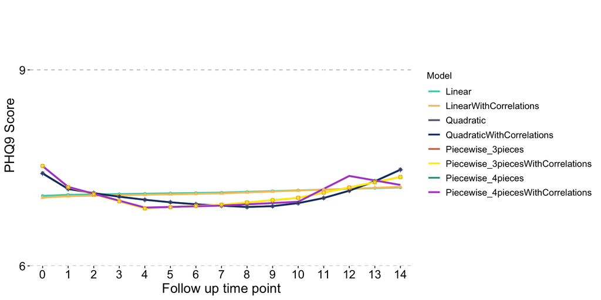

```r
growth_curves_run2 <- ggplot() +
  geom_line(data = dat_dep_run_2,
        aes(x = timepoint, y = score, colour = Model), size = 1) +
  geom_point(data = dat_dep_run_2,
        aes(x = timepoint, y = score, colour = Model, shape=Model), show.legend = F) +
  scale_color_manual(values = pres.palette) +
  labs(x = "Follow up time point", y ="PHQ9 Score") +
  scale_y_continuous(expand = c(0,0), limits = c(6,10), breaks=seq(6, 10, 3)) +
  scale_x_continuous(expand = c(0,0), limits = c(-0.5,14.5), breaks=seq(0, 14, by = 1)) +
  theme(panel.grid.major.y = element_line(size = 0.5,
                                        linetype = 'dashed',
                                        colour = "gray"),
        axis.text = element_text(colour="black", size = 14),
        axis.title = element_text(colour="black", size = 16),
        legend.key = element_blank(),
        legend.text = element_text(colour = "black", size = 11),
        panel.background = element_blank())

growth_curves_run2
```

#### Only pairwise correlations

As these make most theoretical sense and show better mode fit, show the trajectories onluy including residual correlations between adjacent time points to make it easier to compare the models

```r
dat_dep_run_2b<-data.frame(matrix(nrow=15, ncol=4))

colnames(dat_dep_run_2b)<-c("Linear", "Quadratic",  "Piecewise_3Pieces", "Piecewise_4Pieces")


dat_dep_run_2b$Linear <- dep.traj.all$phq_latentGrowthCurve_linear_withpairwiseCorrelations.out$gh5$means_and_variances_data$y_estimated_means$values
dat_dep_run_2b$Piecewise_3Pieces <- dep.traj.all$phq_latentGrowthCurve_piecewise_version2_3pieces_wPairwiseCorrelations.out$gh5$means_and_variances_data$y_estimated_means$values
dat_dep_run_2b$Piecewise_4Pieces <- dep.traj.all$phq_latentGrowthCurve_piecewise_version1_4pieces_wPairwise_correlations.out$gh5$means_and_variances_data$y_estimated_means$values
dat_dep_run_2b$Quadratic <- dep.traj.all$phq_latentGrowthCurve_quadratic_withPairwiseCorrelations.out$gh5$means_and_variances_data$y_estimated_means$values

dat_dep_run_2b$timepoint<-c(0:14)

dat_dep_run_2b<-dat_dep_run_2b%>%pivot_longer(-timepoint, names_to = "Model", values_to = "score")%>%mutate(Model = factor(Model, levels = c("Linear","Quadratic", "Piecewise_3Pieces","Piecewise_4Pieces")))
```

##### Growth Curve Plot

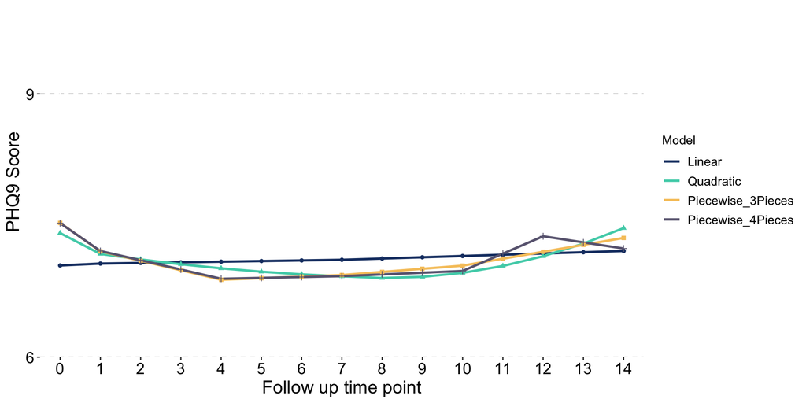

```r
growth_curves_run2b <- ggplot() +
  geom_line(data = dat_dep_run_2b,
        aes(x = timepoint, y = score, colour = Model), size = 1) +
  geom_point(data = dat_dep_run_2b,
        aes(x = timepoint, y = score, colour = Model, shape=Model), show.legend = F) +
  scale_color_manual(values = pres.palette[c(4, 1:3)]) +
  labs(x = "Follow up time point", y ="PHQ9 Score") +
  scale_y_continuous(expand = c(0,0), limits = c(6,10), breaks=seq(6, 10, 3)) +
  scale_x_continuous(expand = c(0,0), limits = c(-0.5,14.5), breaks=seq(0, 14, by = 1)) +
  theme(panel.grid.major.y = element_line(size = 0.5,
                                        linetype = 'dashed',
                                        colour = "gray"),
        axis.text = element_text(colour="black", size = 14),
        axis.title = element_text(colour="black", size = 16),
        legend.key = element_blank(),
        legend.text = element_text(colour = "black", size = 11),
        panel.background = element_blank())

growth_curves_run2b
```

#### Observed and estimated means

lot pairwise correlation versions only. Plot estimated means from model alongside the observed means from the data.

```r
dat_dep_run_2c<-data.frame(matrix(nrow=15, ncol=5))

colnames(dat_dep_run_2c)<-c("Linear","Quadratic", "Piecewise_3Pieces","Piecewise_4Pieces", "Observed")


dat_dep_run_2c$Linear <- dep.traj.all$phq_latentGrowthCurve_linear_withpairwiseCorrelations.out$gh5$means_and_variances_data$y_estimated_means$values
dat_dep_run_2c$Piecewise_3Pieces <- dep.traj.all$phq_latentGrowthCurve_piecewise_version2_3pieces_wPairwiseCorrelations.out$gh5$means_and_variances_data$y_estimated_means$values
dat_dep_run_2c$Piecewise_4Pieces <- dep.traj.all$phq_latentGrowthCurve_piecewise_version1_4pieces_wPairwise_correlations.out$gh5$means_and_variances_data$y_estimated_means$values
dat_dep_run_2c$Quadratic <- dep.traj.all$phq_latentGrowthCurve_quadratic_withPairwiseCorrelations.out$gh5$means_and_variances_data$y_estimated_means$values


dat_dep_run_2c$Observed <- dep.traj.all$phq_latentGrowthCurve_linear_withpairwiseCorrelations.out$gh5$means_and_variances_data$y_observed_means$values

dat_dep_run_2c$timepoint<-c(0:14)

dat_dep_run_2c<-dat_dep_run_2c%>%pivot_longer(-timepoint, names_to = "Model", values_to = "score")%>%mutate(Model = factor(Model, levels = c("Linear","Quadratic","Piecewise_3Pieces","Piecewise_4Pieces", "Observed")))


dat_dep_run_2c <- dat_dep_run_2c %>%
  mutate(Type = case_when(Model == "Observed"~ "Observed",
                          TRUE ~ "Estimated"))
```

##### Growth Curve Plot

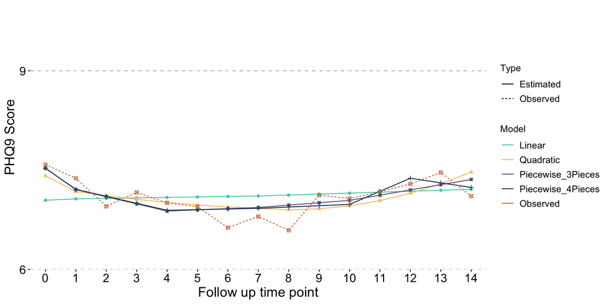

```r
growth_curves_run2c <- ggplot() +
  geom_line(data = dat_dep_run_2c,
        aes(x = timepoint, y = score, colour = Model,linetype=Type)) +
  geom_point(data = dat_dep_run_2c,
        aes(x = timepoint, y = score, colour = Model, shape=Model), show.legend = F) +
  scale_color_manual(values = pres.palette) +
  labs(x = "Follow up time point", y ="PHQ9 Score") +
  scale_y_continuous(expand = c(0,0), limits = c(6,10), breaks=seq(6, 10, 3)) +
  scale_x_continuous(expand = c(0,0), limits = c(-0.5,14.5), breaks=seq(0, 14, by = 1)) +
  theme(panel.grid.major.y = element_line(size = 0.5,
                                        linetype = 'dashed',
                                        colour = "gray"),
        axis.text = element_text(colour="black", size = 14),
        axis.title = element_text(colour="black", size = 16),
        legend.key = element_blank(),
        legend.text = element_text(colour = "black", size = 11),
        panel.background = element_blank())

growth_curves_run2c
```

#### Run 1: all time points

##### Format Data for Plots

```r
dep.traj.run.1 <- readModels("./MPlus_input_lcga/PHQ/Output_Run1_alltimepoints",
                           recursive=TRUE)


dat_dep_run_1<-data.frame(matrix(nrow=18, ncol=3))

colnames(dat_dep_run_1)<-c("Linear", "Quadratic",  "Piecewise3")

#  "LinearCor", "QuadraticCor","Piecewise4", "Piecewise4Cor",, "Piecewise3Cor"

dat_dep_run_1$Linear <-dep.traj.run.1$..MPlus_input_lcga.PHQ.Output_Run1_alltimepoints.phq_latentGrowthCurve_linear.out$gh5$means_and_variances_data$y_estimated_means$values

#dat_dep_run_1$LinearCor<-dep.traj.all$phq_latentGrowthCurve_linear_withpairwiseCorrelations.out$gh5$means_and_variances_data$y_estimated_means$values

dat_dep_run_1$Quadratic<-dep.traj.run.1$..MPlus_input_lcga.PHQ.Output_Run1_alltimepoints.phq_latentGrowthCurve_quadratic.out$gh5$means_and_variances_data$y_estimated_means$values

#dat_dep_run_1$QuadraticCor<-dep.traj.run.1$phq_latentGrowthCurve_quadratic_withPairwiseCorrelations.out$gh5$means_and_variances_data$y_estimated_means$values

#dat_dep_run_1$Piecewise4<-dep.traj.run.1$phq_latentGrowthCurve_piecewise_version1_4pieces.out$gh5$means_and_variances_data$y_estimated_means$values

#dat_dep_run_1$Piecewise4Cor<-dep.traj.run.1$phq_latentGrowthCurve_piecewise_version1_4pieces_wPairwise_correlations.out$gh5$means_and_variances_data$y_estimated_means$values


dat_dep_run_1$Piecewise3<-dep.traj.run.1$..MPlus_input_lcga.PHQ.Output_Run1_alltimepoints.phq_latentGrowthCurve_piecwewise_version2_3pieces.out$gh5$means_and_variances_data$y_estimated_means$values

#dat_dep_run_1$Piecewise3Cor<-dep.traj.run.1$phq_latentGrowthCurve_piecewise_version2_3pieces_wPairwiseCorrelations.out$gh5$means_and_variances_data$y_estimated_means$values


dat_dep_run_1$timepoint<-c(0:17)

dat_dep_run_1<-dat_dep_run_1%>%pivot_longer(-timepoint, names_to = "Model", values_to = "score")%>%mutate(Model = factor(Model, levels = c("Linear","Quadratic","Piecewise3")))
```

##### Growth Curve Plot

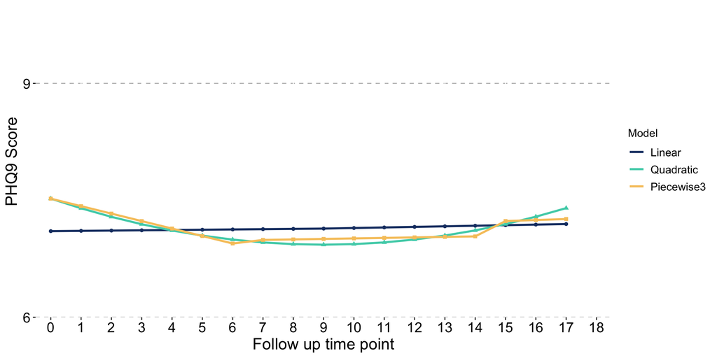

```r
growth_curves_run1 <- ggplot() +
  geom_line(data = dat_dep_run_1,
        aes(x = timepoint, y = score, colour = Model), size = 1) +
  geom_point(data = dat_dep_run_1,
        aes(x = timepoint, y = score, colour = Model, shape=Model), show.legend = F) +
  scale_color_manual(values = pres.palette[c(4, 1:3)]) +
  labs(x = "Follow up time point", y ="PHQ9 Score") +
  scale_y_continuous(expand = c(0,0), limits = c(6,10), breaks=seq(6, 10, 3)) +
  scale_x_continuous(expand = c(0,0), limits = c(-0.5,18.5), breaks=seq(0, 18, by = 1)) +
  theme(panel.grid.major.y = element_line(size = 0.5,
                                        linetype = 'dashed',
                                        colour = "gray"),
        axis.text = element_text(colour="black", size = 14),
        axis.title = element_text(colour="black", size = 16),
        legend.key = element_blank(),
        legend.text = element_text(colour = "black", size = 11),
        panel.background = element_blank())

growth_curves_run1
```

# to do tomorrow on train

3. format outputs so they are less unreadable in markdown